# Anime Database ~ Hito 1 ~

#### Grupo 15

Integrantes: Álvaro Morales, Iván Larraín, Ignacio Ancatripai, Felipe Araya

## Introducción y motivación

En este proyecto, se explorarán los datos y estadisticas presentados en la siguiente [Base de datos de MyAnimeList](https://www.kaggle.com/CooperUnion/anime-recommendations-database).

### Contexto

El consumo global de anime (fuera de Japón) ha experimentado un alza considerable durante la década del 2010, impulsado por la creciente facilidad de acceso a series mediante plataformas de streaming (*Crunchyroll, Funimation, Netflix*, etc) que permiten acceder de manera legal a este contenido previamente solo obtenible por tv o sitios web clandestinos. El nivel de integración a la cultura popular de estas series da paso a que exista un número creciente de datos disponibles sobre las series en si así como del público que las consume. Existen diversas plataformas en donde usuarios pueden discutir acerca de estas series, y algunas que permiten que un usuario califique y/o catalogue series según su experiencia personal con estas. Entre estas se encuentra *MyAnimeList*, la cual será la principal fuente de datos de este proyecto.

[*MyAnimeList*](https://myanimelist.net) es una comunidad virtual de catalogación de anime y manga. Al menos en occidente es la más utilizada de su tipo. Proporciona a sus usuarios un sistema basado en listas para organizar y puntuar anime y/o manga que hayan visto y contactar a otros usuarios con gustos similares, todo esto gracias a una base de datos de anime/manga muy amplia. Los usuarios pueden añadir series a sus listas y marcarlas en diversos estados ("visto", "viendo", "pausado", etc), así como otorgarles una puntuación entre 1-10.

Ha existido desde el 2005, puesta en marcha por Garrett Gyssler, y recibe cerca de 120 millones de visitantes al mes.

La base de datos a utilizar contiene información publica obtenida desde este sitio web, y contiene datos sobre miles de series de anime, usuarios y sus listas recopiladas hasta el año 2018. Estos datos son interesantes de analizar pues contemplan un amplio rango de tiempo, géneros (de series) y usuarios; incluyendo información de ratings y popularidad así como datos relevantes de los usuarios (género, fecha de nacimiento, nacionalidad, etc) que permiten realizar un estudio sobre la composición del público que consume anime y a la vez encontrar posibles relaciones entre las series y los usuarios que las ven, así como realizar un análisis temporal del consumo de estas.

## Exploración de datos

Lo siguiente fue sacado direcamente de kaggle:

AnimeList.csv contiene una lista de anime, con título, sinónimos del título, género, estudio, dueño de la licencia, productor, duración, calificación, puntuación, fecha de emisión, episodios, fuente (manga, novela ligera, etc.) y muchos otros datos importantes.

UserList.csv contiene información sobre los usuarios que ven anime, concretamente el nombre de usuario, la fecha de registro (join_date), la última fecha de conexión, la fecha de nacimiento, el sexo, la ubicación y muchos valores agregados de sus listas de anime.

UserAnimeList.csv contiene listas de anime de todos los usuarios. Por cada registro, aquí está el nombre de usuario, el ID del anime, la puntuación, el estado y la fecha de la última actualización de este registro. Este archivo es muy grande, así que no se tocará por ahora (en su versión raw, existen versiones limpias que si se pueden ocupar)

Este dataset (sin preprocesamiento) contiene:

- 302 675 usuarios únicos (302 573 de ellos con algunos datos demográficos)
- 80 076 112 registros en listas de anime
- 46 358 322 de ellos tienen valoraciones
- 14 478 animes únicos

También se incluyen datos "limpios" en anime_cleaned.csv, animelists_cleaned.csv y users_cleaned.csv. Esta versión limpiada ha truncado a todos los usuarios con un número ridículamente grande de episodios en animes que no tienen tantos episodios, los episodios vistos más grandes que el número de episodios en un anime individual fueron arreglados y los episodios vistos y el watchtime fue recalculado. Para algunos usuarios, la última vez que se conectaron fue en el año 1900, u otros valores extraños, por lo que su última actividad se dedujo de su última marca de tiempo de actualización de la lista de animes.

Muchos usuarios rellenaron incorrectamente el número de episodios vistos o repetidos. En el caso de los animes en los que se han visto más episodios de los que tiene el anime, los episodios vistos se han reescrito como número de episodios de ese anime. El tiempo de visionado y el número de episodios vistos se han corregido en consecuencia. Los usuarios demasiado jóvenes y demasiado viejos, obviamente, se han truncado también.

Habían 6 usuarios con sospechosamente muchos episodios vistos. Fueron truncados, son muy pocos usuarios para afectar a las estadísticas.

### Verifiquemos algunas de estas aseveraciones.

A continuación, comprobaremos algunas de las cosas que asegura el análisis hecho por los autores de este dataset.

UserAnimeList.csv pesa >5GB, y sus versiones filtradas >2GB c/u. Por esto, ignoraremos las versiones raw y filtered. Compararemos las otras para verificar el análisis hecho por los autores.

```python
import numpy as np
import pandas as pd
import matplotlib.pyplot as plt
```

```python
# Raw ~5 GB
# user_animelist = pd.read_csv('database/UserAnimeList.csv') -> Este ocupa mucho espacio (>5GB) asi que se saltará.
user_list = pd.read_csv('database/UserList.csv')
anime_list = pd.read_csv('database/AnimeList.csv')

# Datos limpios ~2GB
animelists_cleaned = pd.read_csv('database/animelists_cleaned.csv')
users_cleaned = pd.read_csv('database/users_cleaned.csv')
anime_cleaned = pd.read_csv('database/anime_cleaned.csv')
```

```python
# tamaños
print("fyi: (rows, columns)")
print(f"user_list: {user_list.shape}")
print(f"anime_list: {anime_list.shape}")
print(f"animelists_cleaned: {animelists_cleaned.shape}")
print(f"users_cleaned: {users_cleaned.shape}")
print(f"anime_cleaned: {anime_cleaned.shape}")
```

```
fyi: (rows, columns)
user_list: (302675, 17)
anime_list: (14478, 31)
animelists_cleaned: (31284030, 11)
users_cleaned: (108711, 17)
anime_cleaned: (6668, 33)
```

```python
animelists_cleaned.info(verbose=False) # listas de anime de los usuarios
```

```
<class 'pandas.core.frame.DataFrame'>
RangeIndex: 31284030 entries, 0 to 31284029
Columns: 11 entries, username to my_tags
dtypes: float64(1), int64(5), object(5)
memory usage: 2.6+ GB
```

```python
users_cleaned.info() # info de los usuarios
```

```
<class 'pandas.core.frame.DataFrame'>
RangeIndex: 108711 entries, 0 to 108710
Data columns (total 17 columns):
 #   Column                    Non-Null Count   Dtype
---  ------                    --------------   -----
 0   username                  108710 non-null  object
 1   user_id                   108711 non-null  int64
 2   user_watching             108711 non-null  int64
 3   user_completed            108711 non-null  int64
 4   user_onhold               108711 non-null  int64
 5   user_dropped              108711 non-null  int64
 6   user_plantowatch          108711 non-null  int64
 7   user_days_spent_watching  108711 non-null  float64
 8   gender                    108711 non-null  object
 9   location                  108706 non-null  object
 10  birth_date                108711 non-null  object
 11  access_rank               0 non-null       float64
 12  join_date                 108711 non-null  object
 13  last_online               108711 non-null  object
 14  stats_mean_score          108711 non-null  float64
 15  stats_rewatched           108711 non-null  float64
 16  stats_episodes            108711 non-null  int64
dtypes: float64(4), int64(7), object(6)
memory usage: 14.1+ MB
```

```python
# ^^^ como todos los campos no nulos son exactamente la cantidad de filas (con algunas excepciones), parece que la limpieza fue bien hecha.
# interesantenemte, hay un usuario con nombre null:
users_cleaned[users_cleaned["username"].isnull()]
```

|  | username | user_id | user_watching | user_completed | user_onhold | user_dropped | user_plantowatch | user_days_spent_watching | gender | location | birth_date | access_rank | join_date | last_online | stats_mean_score | stats_rewatched | stats_episodes |
| --- | --- | --- | --- | --- | --- | --- | --- | --- | --- | --- | --- | --- | --- | --- | --- | --- | --- |
| 51311 | NaN | 300142 | 12 | 158 | 8 | 21 | 62 | 39.304167 | Male | Serbia | 1996-12-30 00:00:00 | NaN | 2010-03-01 00:00:00 | 2018-05-20 04:06:06 | 6.58 | 30.0 | 2524 |

En el dataset de usuarios se encuentra que había una fila en donde username era null. Esto en un comienzo parece ser un dato erróneo pero se decide investigar. Se pudo encontrar a este usuario con la siguiente URL incluyendo su id: https://myanimelist.net/comments.php?id=300142. Su nombre, efectivamente es null. Esto produjo que al leer el archivo .csv se tomara como NaN.

```python
anime_cleaned.info(verbose=False) # info de los anime
```

```
<class 'pandas.core.frame.DataFrame'>
RangeIndex: 6668 entries, 0 to 6667
Columns: 33 entries, anime_id to aired_from_year
dtypes: bool(1), float64(4), int64(6), object(22)
memory usage: 1.6+ MB
```

El creador del dataset menciona que hay 6 usuarios con un número excesivamente alto de episodios.

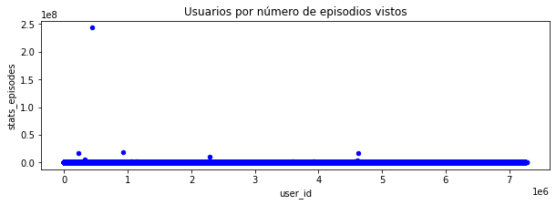

```python
# Veremos a los usuarios por número de episodios vistos
user_list[['username','stats_episodes']].sort_values('stats_episodes', ascending=False).head(10)
# Graficar usuarios por numero de episodios vistos
user_list.plot.scatter(x='user_id', y='stats_episodes', xlabel="Usuario", ylabel="Episodios vistos", color="blue", figsize= (10,3), title='Usuarios por número de episodios vistos')
```

Se pueden ver a simple vista al menos 6 puntos con una cantidad excesivamente mayor al resto. El más alejado es interesante, corresponde al usuario con mayor cantidad de episodios vistos.

```python
# Obtenemos al usuario con mayor cantidad de episodios
user_list[user_list['stats_episodes'] == user_list['stats_episodes'].max()]
```

|  | username | user_id | user_watching | user_completed | user_onhold | user_dropped | user_plantowatch | user_days_spent_watching | gender | location | birth_date | access_rank | join_date | last_online | stats_mean_score | stats_rewatched | stats_episodes |
| --- | --- | --- | --- | --- | --- | --- | --- | --- | --- | --- | --- | --- | --- | --- | --- | --- | --- |
| 45081 | warrose | 443232 | 35 | 2034 | 0 | 1 | 7 | 2601351.02 | Male | San Luis | 1994-01-21 | NaN | 2011-02-01 | 2014-12-28 21:54:00 | 1.01 | 0.0 | 243794881.0 |

Este usuario aparentemente ha visto 243.794.881 episodios en total. Si se accede a su [perfil](https://myanimelist.net/animelist/warrose?status=7&order=4&order2=0) en el sitio web es posible notar con que sus datos son muy probablemente falsos (todas las series con el mismo puntaje, algunas con un número imposiblemente grande de episodios). Esta clase de datos no aportan al dataset y por esa razón son eliminados por el autor para las versiones *clean*.

```python
# Vamos a renombrar el usuario con nombre null a "null"
users_cleaned.loc[users_cleaned["username"].isnull(), "username"] = "null"
# Obtenemos nuevamente al usuario con nombre "null"
users_cleaned[users_cleaned["username"] == "null"]
```

|  | username | user_id | user_watching | user_completed | user_onhold | user_dropped | user_plantowatch | user_days_spent_watching | gender | location | birth_date | access_rank | join_date | last_online | stats_mean_score | stats_rewatched | stats_episodes |
| --- | --- | --- | --- | --- | --- | --- | --- | --- | --- | --- | --- | --- | --- | --- | --- | --- | --- |
| 51311 | null | 300142 | 12 | 158 | 8 | 21 | 62 | 39.304167 | Male | Serbia | 1996-12-30 00:00:00 | NaN | 2010-03-01 00:00:00 | 2018-05-20 04:06:06 | 6.58 | 30.0 | 2524 |

Se puede obtener de los datos actuales los géneros más populares de anime, por dos criterios: Primero, los géneros más populares por número de series producidas de ese género. Segundo, según cuántas personas tienen estos animes en sus listas de anime. Para tener resultados más precisos se consideran solo aquellos usuarios que tengan estos animes en estados "completed" (2) o "watching" (1), pues un uso común de páginas como *MyAnimeList* es marcar animes que el usuario desea ver pero no necesariamente ha visto aún.

```python
# Obtenemos los generos y contamos sus apariciones.
anime_genres_by_anime = anime_cleaned["genre"].str.split(", ", expand=True).stack().value_counts(dropna=False)
```

```python
# Anime lists con animes en estado 1 o 2
animelists_watched_completed = animelists_cleaned[(animelists_cleaned["my_status"] == 1) | (animelists_cleaned["my_status"] == 2)]

# Obtenemos el id y genero de los animes
anime_genres_only = anime_cleaned[["anime_id", "genre"]]
# Unimos los dos dataframes
animelists_watched_completed = animelists_watched_completed.merge(anime_genres_only, on="anime_id")
animelists_watched_completed.head()
# Obtenemos los generos y contamos sus apariciones.
anime_genres_by_lists = animelists_watched_completed["genre"].str.split(", ", expand=True).stack().value_counts(dropna=False)
```

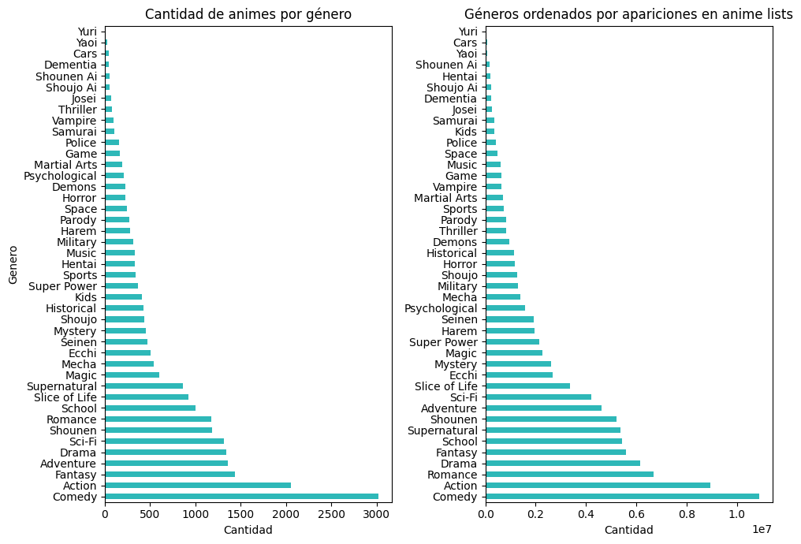

```python
# Graficamos los generos
fig, (ax1,ax2) = plt.subplots(1,2, figsize=(10,4))  # 1 row, 2 columns
anime_genres_by_anime.plot.barh(xlabel="Cantidad", ylabel="Genero", title="Cantidad de animes por género", figsize=(10, 7), ax=ax1, color='#2EB8B8')
anime_genres_by_lists.plot.barh(xlabel="Cantidad", title="Géneros ordenados por apariciones en anime lists", figsize=(10, 7), ax=ax2, color='#2EB8B8')
# tight layout to avoid overlapping
plt.tight_layout()
```

Del gráfico de la izquierda se puede desprender que los animes más producidos son los de género comedia, seguido por acción y fantasía.

Del gráfico de la derecha se desprende que los géneros más vistos siguen siendo comedia y acción, pero el tercer puesto pasa a ser ocupado por el género de romance, y el anterior tercer puesto (fantasía) baja al 5to puesto. Esto puede indicar que el género de romance tiene una audiencia mayor a pesar de que es menos producido que el género de fantasía. Y no es el único, a pesar de que en la mayoria de géneros coincide la cantidad de animes producidos con la popularidad, hay varios casos en donde no calzan como se esperaría.

¿Por que pasa esto? Es una pregunta interesante. Tal vez la gente que ocupa MAL, no necesariamente representa a la mayoría de consumidores de anime. Se podría deducir que los usuarios de MAL, en cierta forma, comparten algunos gustos, que difieren en algunos géneros de el total de consumidores occidentales de anime. Tal vez existen ciertos géneros (como géneros de anime para adultos) que los usuarios prefieren no agregar a sus listas, pues estas son públicas.

Vale destacar que MAL es ocupado por audiencias principalmente occidentales, y los estudios de anime están más interesados en la popularidad en Japón. Puede que allá calzen mejor las estadísticas.

Además, solo viendo los totales, no estamos considerando fechas de emisión o de vista. Es posible que estas disparidades se deban a que algunos géneros no eran muy populares antiguamente, pero tuvieron un boom importante en popularidad a partir de alguna fecha (o viceversa), lo cual podría resultar en una gran cantidad de anime de ciertos géneros, que no fueron muy populares en su época, pero que explotaron en popularidad más recientemente (o viceversa), después de la creación de MAL, en donde usuarios expresaron ésta nueva popularidad.

Otro análisis interesante de realizar es un análisis temporal del anime. Si se agrupan los animes por su año de producción (año en que comienzan a emitirse), se obtiene el siguiente gráfico:

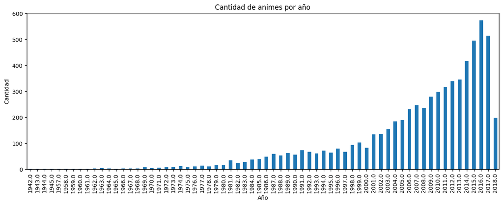

```python
# Agrupar por aired_from_year y contar
anime_cleaned.groupby("aired_from_year").size().plot.bar(xlabel="Año", ylabel="Cantidad", title="Cantidad de animes por año", figsize=(15, 5))
```

En el gráfico se aprecia el explosivo crecimiento que el anime ha tenido en los años 2000, y notablemente en la década del 2010. Se puede también obtener un gráfico de los géneros más populares en periodos de 2 años (es dificil ver las diferencias en un gráfico año a año)

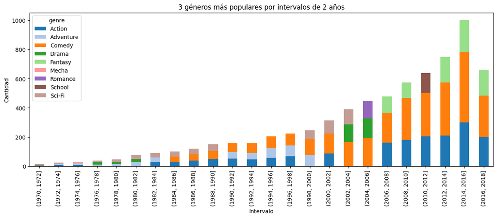

```python
# Se separan los generos primero en filas distintas y luego se pasan a columnas para poder graficarlas.
anime_genres = anime_cleaned["genre"].str.split(", ", expand=True).stack().reset_index(level=1, drop=True).rename("genre")
anime_genres = anime_cleaned.drop("genre", axis=1).join(anime_genres)
anime_genres = anime_genres.groupby(["aired_from_year", "genre"]).size().unstack()
# Se agrupan por cada 2 años, partiendo en 1960. Se ignoran los que vienen antes pues son muy pocos datos y no se aprecian en el gráfico
# (como se puede ver en el gráfico de cantidad de animes por año).
anime_genres = anime_genres.groupby(pd.cut(anime_genres.index, np.arange(1970, 2020, 2))).sum()

# Obtenemos los 3 más populares por año, el resto se quedará como NaN
anime_genres = anime_genres.apply(lambda x: x.nlargest(3), axis=1)

# Plot
colormap = plt.cm.tab20
colors = [colormap(i) for i in np.linspace(0.0, 1.0, 15)]
anime_genres.plot.bar(stacked=True, xlabel="Intervalo", ylabel="Cantidad", title="3 géneros más populares por intervalos de 2 años", figsize=(15, 5), color=colors)
```

De esto se puede apreciar que los generos de acción y comedia están consistentemente en el top 3 de géneros en cada intervalo de tiempo, lo que explica su distribución en los gráficos anteriores. Hay años en donde esto cambia, y hacen su aparición géneros como drama, romance y sci-fi.

Otro análisis interesante de hacer es el de la composición de usuarios del sitio. Se pueden dividir en diversas variables como género, nacionalidad y rangos etarios:

```python
# Se separan los usuarios por gender
genders = users_cleaned['gender'].value_counts()
# Se separan los usuarios por location
locations = users_cleaned['location'].value_counts()
```

```python
# Calculate age from birth date
users_cleaned['age'] = pd.to_datetime('today').year - pd.to_datetime(users_cleaned['birth_date']).dt.year
users_cleaned.head()

# Se separan los usuarios por edad
# Promedio y mediana de edad
print("Promedio de edad: ", users_cleaned['age'].mean())
print("Mediana de edad: ", users_cleaned['age'].median())
```

```
Promedio de edad:  29.125819834239405
Mediana de edad:  29.0
```

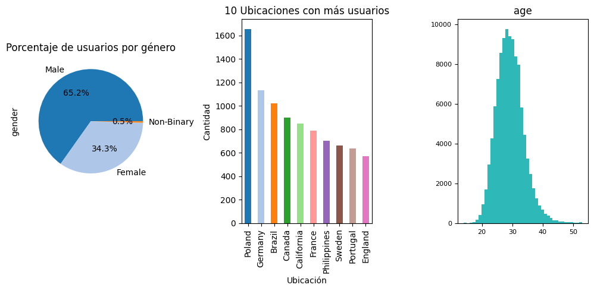

```python
fig, (ax1,ax2,ax3) = plt.subplots(1,3, figsize=(10,4))
genders.plot(kind='pie', autopct='%1.1f%%', figsize=(5, 5), title="Porcentaje de usuarios por género", ax=ax1, colors=colors)
locations.head(10).plot(kind='bar', xlabel="Ubicación", ylabel="Cantidad", title="10 Ubicaciones con más usuarios", figsize=(10, 5), ax=ax2, color=colors)
users_cleaned.hist(column='age', bins=40, xlabelsize=8, ylabelsize=8, figsize=(10, 5), color='#2EB8B8', grid=False, ax=ax3)
plt.tight_layout()
```

Se puede apreciar que la mayoría de usuarios son hombres (65.2%), el país con más usuarios es Polonia, seguido de Alemania y Brasil, y que la media y mediana de edad es 29 años. Pueden surgir, de estos datos y los anteriores mostrados, la pregunta de si existen relaciones entre las características demográficas de los usuarios y las estadísticas de popularidad de los animes por género o por año.

## Propuestas

A partir de los datos expuestos, se pueden hacer las siguientes preguntas:

- ¿Existe alguna relación entre las características de un anime y su popularidad (digase, por ejemplo, el slot de tiempo en que es emitido)?
- ¿Existe alguna relación entre las características de un usuario y los tipos de anime que más ve?
- ¿Existe alguna relación entre las características de un usuario y la puntuación que le pone a ciertos animes o géneros?
- ¿Es posible clasificar a los usuarios para poder recomendarles un anime que pueda ser de su agrado?
- ¿Es posible clasificar a los animes de forma de poder predecir su popularidad en un grupo objetivo de usuarios?

Responder estas preguntas presenta algunos desafíos, principalmente si se trata de clasificar series pues la cantidad de columnas que estas tienen da lugar a que pueda haber una gran variación según cada uno de los distintos parámetros. Es necesario descubrir cómo se relacionan estos parámetros con las medidas objetivo que se buscan estudiar.

# = = = = = = = = = = = = = = = = = = = = = = =

# ~ HITO 2 ~

De las propuestas del Hito 1, las que más detacaron fueron:

- ¿Existe alguna relación entre las características de un usuario y la puntuación que le pone a ciertos animes o géneros?
- ¿Es posible clasificar a los usuarios para poder recomendarles un anime que pueda ser de su agrado?
- ¿Es posible clasificar a los animes de forma de poder predecir su popularidad en un grupo objetivo de usuarios?

Estas 3 apuntan a la misma idea: **¿Podemos recomendarle anime a los usuarios en base a sus gustos?**

Desde ahora el proyecto tomará esa ruta.

#### ¿Por dónde partimos?

Primero que nada, para poder recomendarle animes a los usuarios, es necesario de alguna manera clasificarlos por sus gustos.

A continuación veremos si en este dataset hay suficiente información como para poder identificar grupos de usuarios, en base a los animes que han visto y puntuado.

```python
# para no tener que correr todo de nuevo, partamos por acá
import numpy as np
import pandas as pd
import matplotlib.pyplot as plt
from sklearn.cluster import DBSCAN
from sklearn.decomposition import PCA
from sklearn.cluster import KMeans
from sklearn.neighbors import NearestNeighbors
from scipy.cluster.hierarchy import dendrogram, linkage
from sklearn.cluster import AgglomerativeClustering
from sklearn.metrics import silhouette_score
```

```python
users_cleaned = pd.read_csv('database/users_cleaned.csv')
anime_cleaned = pd.read_csv('database/anime_cleaned.csv')
animelist_cleaned = pd.read_csv('database/animelists_cleaned.csv')
```

**Idea:** Revisar absolutamente todos los anime uno por uno por usuario sería una tarea muy tediosa que consumiría mucha memoria y mucho más tiempo. Por lo tanto, con el fin de encontrar **clusters** de usuarios en base a sus **gustos**, a cada usuario se le tomará el promedio de la **puntuación** que le ha dado a animes **para cada género de anime**.

```python
anime_cleaned.loc[anime_cleaned['genre'].isnull()] # habían 4 animes sin género, los eliminamos
#remove the null values
anime_cleaned = anime_cleaned.dropna(subset=['genre'])
# los géneros son representados por string, los pasamos a listas
anime_genres = anime_cleaned["genre"].str.split(", ", expand=True).stack().reset_index(level=1, drop=True).rename("genre")
genres = {} # todos los géneros de anime disponibles
for genre in anime_genres:
    if genre not in genres:
        genres[genre] = 1

print(genres) # obtenemos todos los géneros posibles. los úsaremos luego
```

```
{'Comedy': 1, 'Supernatural': 1, 'Romance': 1, 'Shounen': 1, 'Parody': 1, 'School': 1, 'Magic': 1, 'Shoujo': 1, 'Drama': 1, 'Fantasy': 1, 'Kids': 1, 'Action': 1, 'Music': 1, 'Slice of Life': 1, 'Josei': 1, 'Harem': 1, 'Shounen Ai': 1, 'Adventure': 1, 'Super Power': 1, 'Sci-Fi': 1, 'Ecchi': 1, 'Seine…
```

Ahora que tenemos todos los géneros posibles, haremos un nuevo dataframe de usuarios, donde iremos guardando el score promedio de cada usuario para cada género.

```python
new_users_df = users_cleaned.copy()[["username", "location", "birth_date"]]
for genre in genres:
    new_users_df[genre] = 0
```

```python
# recordemos que animelist_cleaned tiene todas las entradas de vistos para cada usuario
animelist_cleaned.head()
```

|  | username | anime_id | my_watched_episodes | my_start_date | my_finish_date | my_score | my_status | my_rewatching | my_rewatching_ep | my_last_updated | my_tags |
| --- | --- | --- | --- | --- | --- | --- | --- | --- | --- | --- | --- |
| 0 | karthiga | 21 | 586 | 0000-00-00 | 0000-00-00 | 9 | 1 | NaN | 0 | 2013-03-03 10:52:53 | NaN |
| 1 | karthiga | 59 | 26 | 0000-00-00 | 0000-00-00 | 7 | 2 | NaN | 0 | 2013-03-10 13:54:51 | NaN |
| 2 | karthiga | 74 | 26 | 0000-00-00 | 0000-00-00 | 7 | 2 | NaN | 0 | 2013-04-27 16:43:35 | NaN |
| 3 | karthiga | 120 | 26 | 0000-00-00 | 0000-00-00 | 7 | 2 | NaN | 0 | 2013-03-03 10:53:57 | NaN |
| 4 | karthiga | 178 | 26 | 0000-00-00 | 0000-00-00 | 7 | 2 | 0.0 | 0 | 2013-03-27 15:59:13 | NaN |

```python
def get_genres(anime_id):
    anime = anime_cleaned.loc[anime_cleaned["anime_id"] == anime_id]
    if len(anime) == 0:
        return []
    return anime["genre"].values[0].split(", ")

# random subset of users
users = new_users_df.copy().sample(10000)


# keep anime lists for only the users in the random subset
only_watched = animelist_cleaned.loc[animelist_cleaned["username"].isin(users["username"])]


# user_anime = pd.DataFrame()
only_watched = only_watched.loc[only_watched["my_status"] == 2]
# only users that have watched at most 100 anime
only_watched = only_watched.loc[only_watched.groupby("username")["username"].transform('size') <= 50]
# order by username
only_watched = only_watched.sort_values(by=["username"])

# reset index
only_watched = only_watched.reset_index(drop=True)

n = len(only_watched)
# only_watched.head()
count = {}
current_username = ''
current_user = []
for index, row in only_watched.iterrows():
    # print(row["username"], index)
    if (index == 0):
        current_username = row["username"]
        # get user index
        current_user = users.loc[users["username"] == current_username].index[0]
    if (row["username"] != current_username or index == n - 1):
        # calculate mean
        for genre in count:
            user = users.loc[users["username"] == current_username]
            # change the value of the genre
            genre_score_sum = user[genre]
            users.loc[users["username"] == current_username, genre] = round(genre_score_sum / count[genre], 2)
        current_username = row["username"]
        current_user = users.loc[users["username"] == current_username].index[0]
        count = {}


    username = row["username"]

    anime_id = row["anime_id"]
    anime_genres = get_genres(anime_id)

    for genre in anime_genres:
        if (genre in count):
            count[genre] += 1
        else:
            count[genre] = 1
        users.loc[current_user, genre] += row["my_score"]
    #print(f'{index}/{n}')

users.head(10)
```

|  | username | location | birth_date | Comedy | Supernatural | Romance | Shounen | Parody | School | Magic | ... | Space | Samurai | Thriller | Hentai | Yaoi | Shoujo Ai | Police | Cars | Dementia | Yuri |
| --- | --- | --- | --- | --- | --- | --- | --- | --- | --- | --- | --- | --- | --- | --- | --- | --- | --- | --- | --- | --- | --- |
| 81443 | -Yunomi- | California | 1997-10-28 00:00:00 | 8.21 | 9.00 | 7.69 | 8.29 | 9.0 | 7.92 | 0.00 | ... | 0.0 | 0.0 | 9.00 | 10.00 | 10.0 | 0.0 | 0.0 | 0.0 | 0.0 | 0.0 |
| 91010 | Darknight847 | United States | 1996-01-19 00:00:00 | 0.00 | 0.00 | 0.00 | 0.00 | 0.0 | 0.00 | 0.00 | ... | 0.0 | 0.0 | 0.00 | 0.00 | 0.0 | 0.0 | 0.0 | 0.0 | 0.0 | 0.0 |
| 105348 | clearandsweet | Delaware, USA | 1989-03-01 00:00:00 | 0.00 | 0.00 | 0.00 | 0.00 | 0.0 | 0.00 | 0.00 | ... | 0.0 | 0.0 | 0.00 | 0.00 | 0.0 | 0.0 | 0.0 | 0.0 | 0.0 | 0.0 |
| 73123 | Sparxx1 | Germany | 1992-11-30 00:00:00 | 8.27 | 8.08 | 7.93 | 7.57 | 0.0 | 7.63 | 8.00 | ... | 0.0 | 0.0 | 8.50 | 0.00 | 0.0 | 0.0 | 0.0 | 0.0 | 0.0 | 0.0 |
| 43025 | ownosourus | Vilnius, Lithuania | 1991-05-14 00:00:00 | 0.00 | 0.00 | 0.00 | 0.00 | 0.0 | 0.00 | 0.00 | ... | 0.0 | 0.0 | 0.00 | 0.00 | 0.0 | 0.0 | 0.0 | 0.0 | 0.0 | 0.0 |
| 86376 | invinsiblstanley | Serbia | 1999-04-21 00:00:00 | 0.00 | 0.00 | 0.00 | 0.00 | 0.0 | 0.00 | 0.00 | ... | 0.0 | 0.0 | 0.00 | 0.00 | 0.0 | 0.0 | 0.0 | 0.0 | 0.0 | 0.0 |
| 59577 | ExwireTamer | Ohio probably | 1998-08-07 00:00:00 | 0.00 | 0.00 | 0.00 | 0.00 | 0.0 | 0.00 | 0.00 | ... | 0.0 | 0.0 | 0.00 | 0.00 | 0.0 | 0.0 | 0.0 | 0.0 | 0.0 | 0.0 |
| 59782 | elf_ | Auburn University | 1987-10-14 00:00:00 | 8.50 | 10.00 | 9.00 | 7.00 | 10.0 | 10.00 | 0.00 | ... | 9.0 | 0.0 | 5.00 | 0.00 | 0.0 | 0.0 | 0.0 | 0.0 | 5.0 | 0.0 |
| 8933 | Jazz3302 | São Paulo metropolitan area | 1996-08-08 00:00:00 | 0.00 | 0.00 | 0.00 | 0.00 | 0.0 | 0.00 | 0.00 | ... | 0.0 | 0.0 | 0.00 | 0.00 | 0.0 | 0.0 | 0.0 | 0.0 | 0.0 | 0.0 |
| 62250 | SakuraNishiwaki | Vancouver, British Columbia | 1990-08-22 00:00:00 | 9.33 | 8.46 | 9.50 | 9.50 | 9.0 | 9.33 | 9.25 | ... | 0.0 | 0.0 | 9.67 | 8.25 | 0.0 | 0.0 | 0.0 | 0.0 | 10.0 | 0.0 |

10 rows × 46 columns

Con ésto podemos empezar a hacer clusters para ver que sale. Primero dropeemos algunos features que no nos interesan por ahora.

```python
users_copy = users.copy()
users_copy= users_copy.drop(columns=["username", "location", "birth_date"])
print(len(users_copy))
#get list of columns
columns = users_copy.columns
print(columns)
#remove columns with all 0s
users_copy = users_copy.loc[~(users_copy == 0).all(axis=1)]
print(len(users_copy))
users_copy.head()
```

```
10000
Index(['Comedy', 'Supernatural', 'Romance', 'Shounen', 'Parody', 'School',
       'Magic', 'Shoujo', 'Drama', 'Fantasy', 'Kids', 'Action', 'Music',
       'Slice of Life', 'Josei', 'Harem', 'Shounen Ai', 'Adventure',
       'Super Power', 'Sci-Fi', 'Ecchi', 'Seinen', 'Martial Arts', 'Game',
       'Sports', 'Demons', 'Historical', 'Horror', 'Mystery', 'Psychological',
       'Vampire', 'Mecha', 'Military', 'Space', 'Samurai', 'Thriller',
       'Hentai', 'Yaoi', 'Shoujo Ai', 'Police', 'Cars', 'Dementia', 'Yuri'],
      dtype='object')
2468
```

|  | Comedy | Supernatural | Romance | Shounen | Parody | School | Magic | Shoujo | Drama | Fantasy | ... | Space | Samurai | Thriller | Hentai | Yaoi | Shoujo Ai | Police | Cars | Dementia | Yuri |
| --- | --- | --- | --- | --- | --- | --- | --- | --- | --- | --- | --- | --- | --- | --- | --- | --- | --- | --- | --- | --- | --- |
| 81443 | 8.21 | 9.00 | 7.69 | 8.29 | 9.0 | 7.92 | 0.00 | 0.0 | 8.25 | 9.00 | ... | 0.0 | 0.0 | 9.00 | 10.00 | 10.0 | 0.0 | 0.0 | 0.0 | 0.0 | 0.0 |
| 73123 | 8.27 | 8.08 | 7.93 | 7.57 | 0.0 | 7.63 | 8.00 | 8.5 | 8.07 | 8.33 | ... | 0.0 | 0.0 | 8.50 | 0.00 | 0.0 | 0.0 | 0.0 | 0.0 | 0.0 | 0.0 |
| 59782 | 8.50 | 10.00 | 9.00 | 7.00 | 10.0 | 10.00 | 0.00 | 9.0 | 8.75 | 7.40 | ... | 9.0 | 0.0 | 5.00 | 0.00 | 0.0 | 0.0 | 0.0 | 0.0 | 5.0 | 0.0 |
| 62250 | 9.33 | 8.46 | 9.50 | 9.50 | 9.0 | 9.33 | 9.25 | 0.0 | 8.17 | 9.17 | ... | 0.0 | 0.0 | 9.67 | 8.25 | 0.0 | 0.0 | 0.0 | 0.0 | 10.0 | 0.0 |
| 36208 | 6.43 | 9.50 | 7.67 | 8.50 | 0.0 | 0.00 | 0.00 | 0.0 | 5.50 | 6.60 | ... | 0.0 | 0.0 | 0.00 | 6.67 | 0.0 | 0.0 | 0.0 | 0.0 | 0.0 | 0.0 |

5 rows × 43 columns

```python
# Ordenamos por index
users_copy = users_copy.sort_index()
users_copy.head(10)
```

|  | Comedy | Supernatural | Romance | Shounen | Parody | School | Magic | Shoujo | Drama | Fantasy | ... | Space | Samurai | Thriller | Hentai | Yaoi | Shoujo Ai | Police | Cars | Dementia | Yuri |
| --- | --- | --- | --- | --- | --- | --- | --- | --- | --- | --- | --- | --- | --- | --- | --- | --- | --- | --- | --- | --- | --- |
| 99 | 8.20 | 9.00 | 9.50 | 0.00 | 0.00 | 8.80 | 8.5 | 0.00 | 8.67 | 9.00 | ... | 0.00 | 0.0 | 8.00 | 0.0 | 0.0 | 10.0 | 0.0 | 0.0 | 6.00 | 0.0 |
| 207 | 7.50 | 8.60 | 8.25 | 7.20 | 8.00 | 8.33 | 7.8 | 8.25 | 8.04 | 7.33 | ... | 7.00 | 9.0 | 9.11 | 0.0 | 0.0 | 8.0 | 0.0 | 0.0 | 9.33 | 0.0 |
| 267 | 5.00 | 7.29 | 6.33 | 5.00 | 0.00 | 5.67 | 8.0 | 0.00 | 6.67 | 8.00 | ... | 0.00 | 0.0 | 8.33 | 0.0 | 0.0 | 0.0 | 5.0 | 0.0 | 10.00 | 0.0 |
| 350 | 7.45 | 8.43 | 7.67 | 8.08 | 9.00 | 7.00 | 7.5 | 7.00 | 8.20 | 8.00 | ... | 0.00 | 0.0 | 10.00 | 0.0 | 0.0 | 0.0 | 10.0 | 0.0 | 9.00 | 0.0 |
| 390 | 9.40 | 0.00 | 8.67 | 10.00 | 10.00 | 9.00 | 8.0 | 9.00 | 9.00 | 0.00 | ... | 0.00 | 0.0 | 0.00 | 0.0 | 0.0 | 0.0 | 0.0 | 0.0 | 0.00 | 0.0 |
| 512 | 0.95 | 3.57 | 3.50 | 1.60 | 0.00 | 2.25 | 0.0 | 5.00 | 0.69 | 0.54 | ... | 0.00 | 0.0 | 0.00 | 0.0 | 0.0 | 0.0 | 0.0 | 0.0 | 0.00 | 0.0 |
| 550 | 10.00 | 0.00 | 10.00 | 0.00 | 0.00 | 10.00 | 10.0 | 10.00 | 10.00 | 10.00 | ... | 0.00 | 0.0 | 0.00 | 0.0 | 0.0 | 0.0 | 0.0 | 0.0 | 0.00 | 0.0 |
| 558 | 6.00 | 6.50 | 8.18 | 3.30 | 9.00 | 8.00 | 4.0 | 8.00 | 7.82 | 6.33 | ... | 0.00 | 0.0 | 9.25 | 0.0 | 0.0 | 8.0 | 9.0 | 0.0 | 10.00 | 0.0 |
| 678 | 7.67 | 9.75 | 8.00 | 7.67 | 8.17 | 7.33 | 9.0 | 8.00 | 8.33 | 7.89 | ... | 8.33 | 9.5 | 9.00 | 0.0 | 0.0 | 0.0 | 9.0 | 0.0 | 0.00 | 0.0 |
| 761 | 9.10 | 8.25 | 0.00 | 8.77 | 0.00 | 0.00 | 8.5 | 0.00 | 8.25 | 9.05 | ... | 0.00 | 9.0 | 0.00 | 0.0 | 0.0 | 0.0 | 0.0 | 0.0 | 0.00 | 0.0 |

10 rows × 43 columns

Ocupemos K-means:

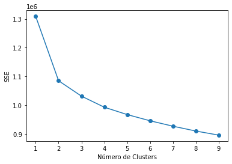

```python
# cluster users with k-means
test_data = users_copy.copy()

SSE = []
numClusters = list(range(1, 10))
for k in numClusters:
    k_means = KMeans(n_clusters=k, n_init=10, random_state=1)
    k_means.fit(test_data)
    SSE.append(k_means.inertia_)

plt.plot(numClusters, SSE, marker="o")
plt.xlabel('Número de Clusters')
plt.ylabel('SSE')
plt.show()
```

Parecen haber 4 clusters:

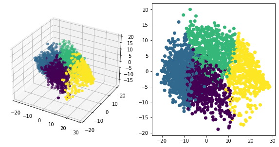

```python
kmeans = KMeans(n_clusters=4, max_iter=50, random_state=1)
kmeans.fit(test_data)

pca = PCA(n_components=2).fit(test_data)
pca_2d = pca.transform(test_data)

# plt.scatter(pca_2d[:, 0], pca_2d[:, 1], c=kmeans.labels_)

# pca in 3d
pca = PCA(n_components=3).fit(test_data)
pca_3d = pca.transform(test_data)


# show 2d and 3d plots side to side
fig = plt.figure(figsize=(10, 5))
ax = fig.add_subplot(121, projection='3d')
ax.scatter(pca_3d[:, 0], pca_3d[:, 1], pca_3d[:, 2], c=kmeans.labels_)
ax = fig.add_subplot(122)
ax.scatter(pca_2d[:, 0], pca_2d[:, 1], c=kmeans.labels_)
plt.show()
```

Se pueden apreciar los 4 clusters, aunque parece haber bastante overlap entre ellos. Probemos con Agglomerative Clustering:

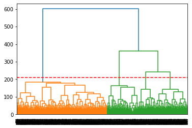

```python
from scipy.cluster.hierarchy import dendrogram, linkage
Z = linkage(test_data, 'ward', metric='euclidean')
dn = dendrogram(Z, orientation='top')
plt.axhline(y=210, color='r', linestyle='--')
plt.show()
```

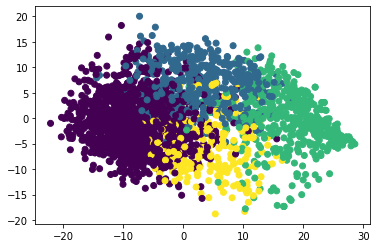

```python
# Agglomerative Clustering
from sklearn.cluster import AgglomerativeClustering
agg = AgglomerativeClustering(n_clusters=None,distance_threshold=210, affinity='euclidean', linkage='ward')

agg.fit(test_data)

plt.scatter(pca_2d[:, 0], pca_2d[:, 1], c=agg.labels_)
```

```python
# Kmeans
print("K-means", silhouette_score(test_data, kmeans.labels_))

# Agglomerative
print("Agglomerative", silhouette_score(test_data, agg.labels_))
```

```
K-means 0.08477722364681323
Agglomerative 0.07940766916809777
```

Ocupando Sillhouette Score, parece que el mejor que k-means.

¡Es posible encontrar grupos! Esto nos indica que tal vez sí sea posible recomendar animes en base a "los gustos" de los usuarios. Ahora intentemos identificar a los animes más gustados para ciertos grupos de usuarios. Esta vez, ocupemos más features, y no acotemos a los usuarios.

```python
# Escogemos las columnas más representativas para los anime
anime = anime_cleaned[['anime_id', 'title', 'genre', 'type', 'episodes', 'score', 'members']]

# agregamos user_id a animelists_cleaned
animelists = animelist_cleaned.merge(users_cleaned[['user_id', 'username']], on='username')

# LIBERO MEMORIA
del animelist_cleaned

# Solo nos interesan los animes que han sido completados (2), no los plan-to-watch o dropped.
animelists = animelists[animelists['my_status'] == 2]
```

```python
# creamos un dataframe con las columnas user_id, anime_id y my_score
score = animelists[['user_id', 'anime_id', 'my_score']]
score.head()
```

|  | user_id | anime_id | my_score |
| --- | --- | --- | --- |
| 1 | 2255153 | 59 | 7 |
| 2 | 2255153 | 74 | 7 |
| 3 | 2255153 | 120 | 7 |
| 4 | 2255153 | 178 | 7 |
| 5 | 2255153 | 210 | 7 |

```python
# dropeamos las cosas de anime que no necesitamos
anime1 = anime.drop(columns=['title', 'members', 'score'])

# conseguimos cada genero como su propia columna, donde 1 significa que el anime tiene ese genero, 0 si no.
anime2 = anime1.join(anime1['genre'].str.get_dummies(', '))

# la misma idea, pero con el tipo de trasmición (TV, OVA, etc)
anime3 = anime1.join(anime1['type'].str.get_dummies(', '))

#dropeamos lo que no vamos a ocupar
anime4 = anime3.drop(columns=['genre', 'type'])
anime5 = anime2.drop(columns=['genre', 'type'])

# MERGE de anime4 y anime5 por anime_id
anime6 = anime4.merge(anime5, on='anime_id')

# correciones menores
anime7 = anime6.drop(columns=['episodes_y', 'Music_y'])
anime8 = anime7.rename(columns={'episodes_x': 'episodes', 'Music_x': 'Music'})

# MERGE de anime6 y score con anime_id
score_anime = anime8.merge(score, on='anime_id')
score_anime.head()
```

|  | anime_id | episodes | Movie | Music | ONA | OVA | Special | TV | Action | Adventure | ... | Space | Sports | Super Power | Supernatural | Thriller | Vampire | Yaoi | Yuri | user_id | my_score |
| --- | --- | --- | --- | --- | --- | --- | --- | --- | --- | --- | --- | --- | --- | --- | --- | --- | --- | --- | --- | --- | --- |
| 0 | 11013 | 12 | 0 | 0 | 0 | 0 | 0 | 1 | 0 | 0 | ... | 0 | 0 | 0 | 1 | 0 | 0 | 0 | 0 | 2255153 | 8 |
| 1 | 11013 | 12 | 0 | 0 | 0 | 0 | 0 | 1 | 0 | 0 | ... | 0 | 0 | 0 | 1 | 0 | 0 | 0 | 0 | 2485327 | 7 |
| 2 | 11013 | 12 | 0 | 0 | 0 | 0 | 0 | 1 | 0 | 0 | ... | 0 | 0 | 0 | 1 | 0 | 0 | 0 | 0 | 4511507 | 7 |
| 3 | 11013 | 12 | 0 | 0 | 0 | 0 | 0 | 1 | 0 | 0 | ... | 0 | 0 | 0 | 1 | 0 | 0 | 0 | 0 | 5341448 | 8 |
| 4 | 11013 | 12 | 0 | 0 | 0 | 0 | 0 | 1 | 0 | 0 | ... | 0 | 0 | 0 | 1 | 0 | 0 | 0 | 0 | 3895 | 7 |

5 rows × 52 columns

```python
#LIBERO MEMORIA
del anime1
del anime2
del anime3
del anime4
del anime5
del anime6
del anime7
del anime8
```

¡Con ésto tenemos nuestros scores! Van de 0 a 10. Pero recordemos que en las columnas de los géneros, solo tenemos 0 y 1. Sería bueno multiplicarlas por my_score para que los valores sean más representativos.

```python
generos = ['Action', 'Adventure', 'Cars', 'Comedy', 'Dementia', 'Demons', 'Drama', 'Ecchi', 'Fantasy', 'Game', 'Harem', 'Hentai',
'Historical', 'Horror', 'Josei', 'Kids', 'Magic', 'Martial Arts', 'Mecha', 'Military', 'Mystery', 'Parody', 'Police',	'Psychological',
'Romance',	'Samurai', 'School', 'Sci-Fi', 'Seinen', 'Shoujo', 'Shoujo Ai',	'Shounen', 'Shounen Ai', 'Slice of Life', 'Space',	'Sports',
'Super Power',	'Supernatural',	'Thriller','Vampire', 'Yaoi','Yuri']
#reemplazar valores de las columnas con nombre de generos en score_anime por el valor de my_score cuando las columnas tengan valor 1
for i in generos:
    score_anime[i] = score_anime[i] * score_anime['my_score']

score_anime.head()
```

|  | anime_id | episodes | Movie | Music | ONA | OVA | Special | TV | Action | Adventure | ... | Space | Sports | Super Power | Supernatural | Thriller | Vampire | Yaoi | Yuri | user_id | my_score |
| --- | --- | --- | --- | --- | --- | --- | --- | --- | --- | --- | --- | --- | --- | --- | --- | --- | --- | --- | --- | --- | --- |
| 0 | 11013 | 12 | 0 | 0 | 0 | 0 | 0 | 1 | 0 | 0 | ... | 0 | 0 | 0 | 8 | 0 | 0 | 0 | 0 | 2255153 | 8 |
| 1 | 11013 | 12 | 0 | 0 | 0 | 0 | 0 | 1 | 0 | 0 | ... | 0 | 0 | 0 | 7 | 0 | 0 | 0 | 0 | 2485327 | 7 |
| 2 | 11013 | 12 | 0 | 0 | 0 | 0 | 0 | 1 | 0 | 0 | ... | 0 | 0 | 0 | 7 | 0 | 0 | 0 | 0 | 4511507 | 7 |
| 3 | 11013 | 12 | 0 | 0 | 0 | 0 | 0 | 1 | 0 | 0 | ... | 0 | 0 | 0 | 8 | 0 | 0 | 0 | 0 | 5341448 | 8 |
| 4 | 11013 | 12 | 0 | 0 | 0 | 0 | 0 | 1 | 0 | 0 | ... | 0 | 0 | 0 | 7 | 0 | 0 | 0 | 0 | 3895 | 7 |

5 rows × 52 columns

```python
# agrupamos a usuarios, y les sacamos los promedios.
users = (score_anime
         .drop(columns=['anime_id', 'my_score'])
         .groupby(by='user_id')
         .mean())
users = users.drop(columns=['episodes'])
users.head()
```

| user_id | Movie | Music | ONA | OVA | Special | TV | Action | Adventure | Cars | Comedy | ... | Shounen Ai | Slice of Life | Space | Sports | Super Power | Supernatural | Thriller | Vampire | Yaoi | Yuri |
| --- | --- | --- | --- | --- | --- | --- | --- | --- | --- | --- | --- | --- | --- | --- | --- | --- | --- | --- | --- | --- | --- |
| 1 | 0.154930 | 0.0 | 0.000000 | 0.136150 | 0.009390 | 0.699531 | 3.211268 | 2.046948 | 0.173709 | 3.821596 | ... | 0.000000 | 1.234742 | 0.464789 | 0.680751 | 0.892019 | 1.272300 | 0.150235 | 0.112676 | 0.0 | 0.0 |
| 3 | 0.238095 | 0.0 | 0.015873 | 0.134921 | 0.079365 | 0.531746 | 3.269841 | 1.968254 | 0.000000 | 4.103175 | ... | 0.000000 | 1.555556 | 0.206349 | 0.000000 | 0.880952 | 1.269841 | 0.468254 | 0.119048 | 0.0 | 0.0 |
| 4 | 0.102334 | 0.0 | 0.005386 | 0.050269 | 0.044883 | 0.797127 | 2.815081 | 1.436266 | 0.000000 | 2.779174 | ... | 0.105925 | 1.021544 | 0.283662 | 0.299820 | 0.691203 | 1.678636 | 0.172352 | 0.125673 | 0.0 | 0.0 |
| 20 | 0.258824 | 0.0 | 0.000000 | 0.047059 | 0.023529 | 0.670588 | 4.376471 | 3.400000 | 0.000000 | 3.247059 | ... | 0.000000 | 0.941176 | 0.200000 | 0.494118 | 1.188235 | 1.917647 | 0.717647 | 0.094118 | 0.0 | 0.0 |
| 36 | 0.131772 | 0.0 | 0.029283 | 0.086384 | 0.040996 | 0.711567 | 2.282577 | 1.169839 | 0.011713 | 2.235725 | ... | 0.000000 | 1.317716 | 0.571010 | 0.095168 | 0.218155 | 1.004392 | 0.197657 | 0.124451 | 0.0 | 0.0 |

5 rows × 48 columns

Por fin tenemos todo para hacer clustering con k-means:

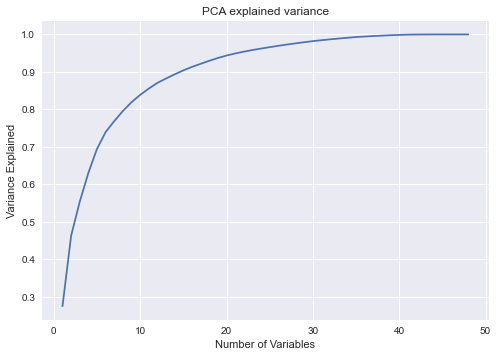

```python
from mpl_toolkits.mplot3d import Axes3D

# reduccion de dimesionalidad
pca = PCA()
pca.fit(users)
acc_var = np.cumsum(pca.explained_variance_ratio_)

plt.style.use('seaborn')
plt.plot(range(1, len(acc_var)+1), acc_var)
plt.title('PCA explained variance')
plt.xlabel('Number of Variables')
_ = plt.ylabel('Variance Explained')
```

Si se escogen 20 variables, se explica el 90% de la varianza.

```python
#
number_of_components = 20
pca.set_params(n_components=number_of_components)
pca.fit(users)
users_pca = pca.transform(users)
users_pos_pca = pd.DataFrame(users_pca)
users_pos_pca['user_id'] = users.index
users_pos_pca = users_pos_pca.set_index('user_id')
```

Veamos cuantos clusters deberían haber con el método del codo:

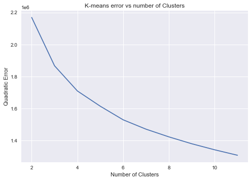

```python
inertia = []
scores = []
for n_clusters in range(2, 12):
    kmeans = KMeans(n_clusters=n_clusters, n_jobs=-1)
    kmeans.fit(users_pos_pca)
    inertia.append(kmeans.inertia_)
plt.plot(range(2, 12), inertia)
plt.xlabel('Number of Clusters')
plt.ylabel('Quadratic Error')
plt.grid(True)
_ = plt.title('K-means error vs number of Clusters')
```

Observamos por el método del codo que encontramos 6 clusters.

```python
#project the users feature vector in 3 dimensions
users_with_label = pd.DataFrame(PCA(n_components=3).fit_transform(users))
users_with_label['user_id'] = users.index
users_with_label = users_with_label.set_index('user_id')

#find each user's cluster
kmeans = KMeans(n_clusters=6, n_init=30, n_jobs=-1)
users_with_label['label'] = kmeans.fit_predict(users_pos_pca)
users_with_label.head()
```

| user_id | 0 | 1 | 2 | label |
| --- | --- | --- | --- | --- |
| 1 | 0.596041 | -0.200280 | 0.699218 | 4 |
| 3 | 0.216887 | -0.198625 | 0.392388 | 4 |
| 4 | -0.805075 | -0.251817 | 0.235966 | 4 |
| 20 | 1.289311 | -2.365785 | 0.399015 | 0 |
| 36 | -2.396534 | -0.755628 | 0.364581 | 4 |

Plot de k-means con 6 clusters:

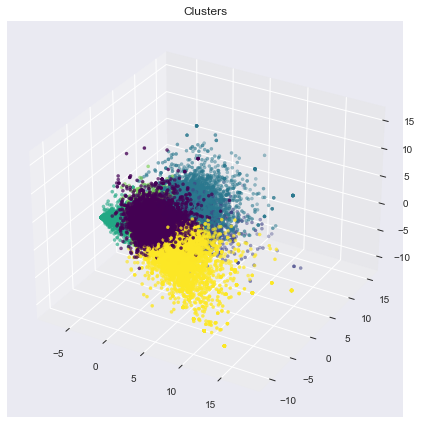

```python
fig = plt.figure()
ax = Axes3D(fig)

ax.scatter(users_with_label[0], users_with_label[1], users_with_label[2], c=users_with_label['label'].to_numpy(), cmap='viridis', s=10)
_ = plt.title('Clusters')
```

Notemos que ahora los clusters son más "difusos", sigue habiendo bastante overlap, pero aún así se distinguen entre sí.

```python
print('Cluster ID     Number of users in cluster')
for idx, val in (pd.get_dummies(users_with_label['label'])).sum().iteritems():
    print(f'{idx}              {val}')
```

```
Cluster ID     Number of users in cluster
0              23573
1              20029
2              8584
3              10682
4              36533
5              8848
```

```python
score_user = score.join(users_with_label[['label']], on='user_id')
score_user.head()
```

|  | user_id | anime_id | my_score | label |
| --- | --- | --- | --- | --- |
| 1 | 2255153 | 59 | 7 | 2 |
| 2 | 2255153 | 74 | 7 | 2 |
| 3 | 2255153 | 120 | 7 | 2 |
| 4 | 2255153 | 178 | 7 | 2 |
| 5 | 2255153 | 210 | 7 | 2 |

De aquí obtuvimos un dataframe con cada usuario con su cluster correspondiente.

Acá generamos un dataframe agrupado por el cluster y por el anime ID, donde cada anime tiene su score promedio, y cuantas veces fue valorado (count).

```python
groups = (score_user[['anime_id', 'my_score', 'label']]
          .groupby(by=['label', 'anime_id'])
          .my_score.agg(['mean', 'count']))
groups.head()
```

| label | anime_id | mean | count |
| --- | --- | --- | --- |
| 0 | 1 | 8.878896 | 10396 |
|  | 5 | 8.429686 | 5895 |
|  | 6 | 8.340652 | 7424 |
|  | 7 | 7.586888 | 2227 |
|  | 8 | 7.140845 | 213 |

Le añadimos la columna objetivo, que es el producto de mean y count. Esto es para darle más peso a los animes que han sido valorados muchas veces, y menos a los que han sido valorados pocas veces.

```python
groups['obj'] = groups['mean']*groups['count']
groups.head()
```

| label | anime_id | mean | count | obj |
| --- | --- | --- | --- | --- |
| 0 | 1 | 8.878896 | 10396 | 92305.0 |
|  | 5 | 8.429686 | 5895 | 49693.0 |
|  | 6 | 8.340652 | 7424 | 61921.0 |
|  | 7 | 7.586888 | 2227 | 16896.0 |
|  | 8 | 7.140845 | 213 | 1521.0 |

Ya no necesitamos lo otro, obj representa todo.

```python
groups_obj = groups[['obj']].dropna()
groups_obj.head()
```

| label | anime_id | obj |
| --- | --- | --- |
| 0 | 1 | 92305.0 |
|  | 5 | 49693.0 |
|  | 6 | 61921.0 |
|  | 7 | 16896.0 |
|  | 8 | 1521.0 |

Con esto, tenemos todo para ordenar los animes por cluster y por score objetivo. A conticuación, mostramos el TOP 10 de animes para cada cluster.

```python
cats = groups_obj.index.get_level_values(0).unique().tolist()
rec = []
for cat in cats:
    rec.append(
        groups_obj
        .loc[cat]
        .sort_values(by='obj', ascending=False)
        .reset_index()
        .join(
            anime[['title', 'anime_id']].set_index('anime_id'),
            on='anime_id')
        ['title']
        .rename(cat)
    )
rec = pd.concat(rec, axis=1)
rec.head(10)
```

|  | 0 | 1 | 2 | 3 | 4 | 5 |
| --- | --- | --- | --- | --- | --- | --- |
| 0 | Death Note | Toradora! | Ouran Koukou Host Club | Death Note | Death Note | Death Note |
| 1 | Code Geass: Hangyaku no Lelouch | Angel Beats! | Vampire Knight | Code Geass: Hangyaku no Lelouch | Sen to Chihiro no Kamikakushi | Naruto |
| 2 | Code Geass: Hangyaku no Lelouch R2 | Sword Art Online | Fruits Basket | Fullmetal Alchemist: Brotherhood | Shingeki no Kyojin | Dragon Ball Z |
| 3 | Fullmetal Alchemist: Brotherhood | Death Note | Death Note | Angel Beats! | Code Geass: Hangyaku no Lelouch | Fullmetal Alchemist |
| 4 | Fullmetal Alchemist | Clannad | Sen to Chihiro no Kamikakushi | Code Geass: Hangyaku no Lelouch R2 | Toradora! | Dragon Ball |
| 5 | Elfen Lied | Highschool of the Dead | Vampire Knight: Guilty | Elfen Lied | Angel Beats! | Fullmetal Alchemist: Brotherhood |
| 6 | Sen to Chihiro no Kamikakushi | Shingeki no Kyojin | Kaichou wa Maid-sama! | Shingeki no Kyojin | Steins;Gate | Shingeki no Kyojin |
| 7 | Shingeki no Kyojin | No Game No Life | Howl no Ugoku Shiro | Sword Art Online | Fullmetal Alchemist: Brotherhood | Code Geass: Hangyaku no Lelouch |
| 8 | Cowboy Bebop | Zero no Tsukaima | Lovely★Complex | Toradora! | Code Geass: Hangyaku no Lelouch R2 | Dragon Ball GT |
| 9 | Neon Genesis Evangelion | High School DxD | Kimi ni Todoke | Fullmetal Alchemist | Mahou Shoujo Madoka★Magica | Sword Art Online |

Son animes como éstos que parecen ser responsables por el overlap entre los clusters. ¿En que afecta esto a nuetro objetivo? Pues como son tan unánimes en su popularidad, para lograr identificar clusters, no son más que ruido. Por lo tanto, para lograr hacer recomendaciones de anime, no los debemos tomar en cuenta.

Incluso dentro de un cluster, al momento de intentar subdividirlo, podrían volver a aparecer animes como éstos, y volver a ser ruido. Habrá que tener cuidado con estos más adelante.

### Conclusiones

- Logramos identificar, de cierta forma, grupos de usuarios con gustos similares.
- Tal vez esto indique que es posible recomendarles anime en base a sus gustos.
- A su vez, mediante una mayor exploración y agregación de los datos se puede buscar obtener clusters más pequeños representando un set de recomendaciones para un usuario con datos más específicos.
- A pesar de tener clusters definidos, hay bastante overlap entre ellos, pero tiene sentido, puesto que existen animes que son populares con todos. Hay que tener esto en cuenta a la hora de recomendar.

# = = = = = = = = = = = = = = = = = = = = = = =

# ~ Hito 3 ~

Nuestro objetivo principal continúa siendo el mismo: Ver si es posible recomendar anime a usuarios a partir de sus gustos.

Para ello, continuaremos experimentando en base a clustering, extendiendo el trabajo iniciado en el Hito 2.

Además, es interesante ver si es posible predecir si un anime será "bueno" o "exitoso" a partir de sus características. Un modelo de clasificación podría ser útil para esto.

Esto nos deja con las siguentes preguntas:

- ¿Podemos recomendarle anime a los usuarios en base a sus gustos?
- ¿Existe alguna relación entre las características de un usuario y la puntuación que le pone a ciertos animes o géneros?
- ¿Se puede clasificar a los animes para poder predecir su popularidad o éxito?

Por lo tanto, nuestras propuestas experimentales son las siguientes:

- **1**: Hacer clustering de los usuarios c/r a sus gustos, y luego hacer clustering de esos clusters, a modo de ir obteniendo animes cada vez más precisos con respecto a los gustos de ciertos grupos de usuarios.
- **2**: Explorar las caracteristicas de los usuarios que componen estos clusters, a modo de ver si existe alguna relación entre las características del usuario y cuales son los animes más populares de su cluster.
- **3**: Clasificar los animes en base a sus características, a modo de poder predecir si un anime será exitoso o no.

```python
import numpy as np
import pandas as pd
import matplotlib.pyplot as plt
from sklearn.cluster import DBSCAN
from sklearn.decomposition import PCA
from sklearn.cluster import KMeans
from sklearn.neighbors import NearestNeighbors
from scipy.cluster.hierarchy import dendrogram, linkage
from sklearn.cluster import AgglomerativeClustering
from sklearn.metrics import silhouette_score
from sklearn.tree import export_graphviz
from IPython.display import Image
from sklearn.tree import DecisionTreeClassifier
from sklearn.metrics import classification_report
from sklearn.metrics import confusion_matrix
from sklearn.utils.multiclass import unique_labels
from sklearn.model_selection import train_test_split
from sklearn.metrics import accuracy_score
import seaborn as sb
import seaborn as sns
from sklearn.preprocessing import LabelEncoder
from sklearn import metrics
from matplotlib import rcParams
import joblib
```

## Experimento 1 (cont.)

### ¿Podemos recomendarle anime a los usuarios en base a sus gustos?

Antes de continuar, detrás de escena generamos los siguientes csv's: `score_anime.csv`, `score.csv` y `users.csv`, que guardan las tablas del mismo nombre definidos más arriba, en el Hito 2. Correr todo ocupa más memoria de la que tenemos, así que este checkpoint es necesario. En todo caso, es exactamente la misma data.

Ahora, retomando de donde quedamos en el Hito 2, volvemos a generar los clusters. Esta vez decidimos que 4 clusters son un mejor resultado del método del codo, y no 6. Más adelante explicaremos por qué:

```python
users = pd.read_csv('database/hito3/users.csv', index_col=0)
users.head()
```

| user_id | Movie | Music | ONA | OVA | Special | TV | Action | Adventure | Cars | Comedy | ... | Shounen Ai | Slice of Life | Space | Sports | Super Power | Supernatural | Thriller | Vampire | Yaoi | Yuri |
| --- | --- | --- | --- | --- | --- | --- | --- | --- | --- | --- | --- | --- | --- | --- | --- | --- | --- | --- | --- | --- | --- |
| 1 | 0.154930 | 0.0 | 0.000000 | 0.136150 | 0.009390 | 0.699531 | 3.211268 | 2.046948 | 0.173709 | 3.821596 | ... | 0.000000 | 1.234742 | 0.464789 | 0.680751 | 0.892019 | 1.272300 | 0.150235 | 0.112676 | 0.0 | 0.0 |
| 3 | 0.238095 | 0.0 | 0.015873 | 0.134921 | 0.079365 | 0.531746 | 3.269841 | 1.968254 | 0.000000 | 4.103175 | ... | 0.000000 | 1.555556 | 0.206349 | 0.000000 | 0.880952 | 1.269841 | 0.468254 | 0.119048 | 0.0 | 0.0 |
| 4 | 0.102334 | 0.0 | 0.005386 | 0.050269 | 0.044883 | 0.797127 | 2.815081 | 1.436266 | 0.000000 | 2.779174 | ... | 0.105925 | 1.021544 | 0.283662 | 0.299820 | 0.691203 | 1.678636 | 0.172352 | 0.125673 | 0.0 | 0.0 |
| 20 | 0.258824 | 0.0 | 0.000000 | 0.047059 | 0.023529 | 0.670588 | 4.376471 | 3.400000 | 0.000000 | 3.247059 | ... | 0.000000 | 0.941176 | 0.200000 | 0.494118 | 1.188235 | 1.917647 | 0.717647 | 0.094118 | 0.0 | 0.0 |
| 36 | 0.131772 | 0.0 | 0.029283 | 0.086384 | 0.040996 | 0.711567 | 2.282577 | 1.169839 | 0.011713 | 2.235725 | ... | 0.000000 | 1.317716 | 0.571010 | 0.095168 | 0.218155 | 1.004392 | 0.197657 | 0.124451 | 0.0 | 0.0 |

5 rows × 48 columns

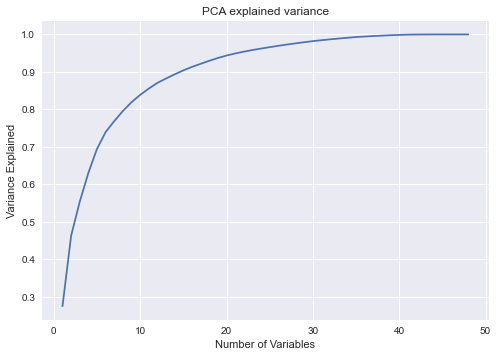

```python
from mpl_toolkits.mplot3d import Axes3D

# reduccion de dimesionalidad
pca = PCA()
pca.fit(users)
acc_var = np.cumsum(pca.explained_variance_ratio_)

plt.style.use('seaborn')
plt.plot(range(1, len(acc_var)+1), acc_var)
plt.title('PCA explained variance')
plt.xlabel('Number of Variables')
_ = plt.ylabel('Variance Explained')
```

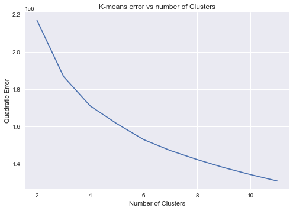

```python
number_of_components = 20
pca.set_params(n_components=number_of_components)
pca.fit(users)
users_pca = pca.transform(users)
users_pos_pca = pd.DataFrame(users_pca)
users_pos_pca['user_id'] = users.index
users_pos_pca = users_pos_pca.set_index('user_id')
# elbow
inertia = []
scores = []
for n_clusters in range(2, 12):
    kmeans = KMeans(n_clusters=n_clusters)
    kmeans.fit(users_pos_pca)
    inertia.append(kmeans.inertia_)
plt.plot(range(2, 12), inertia)
plt.xlabel('Number of Clusters')
plt.ylabel('Quadratic Error')
plt.grid(True)
_ = plt.title('K-means error vs number of Clusters')
```

```python
#project the users feature vector in 3 dimensions
users_with_label = pd.DataFrame(PCA(n_components=3).fit_transform(users))
users_with_label['user_id'] = users.index
users_with_label = users_with_label.set_index('user_id')

#find each user's cluster
kmeans = KMeans(n_clusters=4, n_init=30)
users_with_label['label'] = kmeans.fit_predict(users_pos_pca)
# users_with_label.to_csv('database/hito3/users_with_label.csv')
users_with_label.head()
```

| user_id | 0 | 1 | 2 | label |
| --- | --- | --- | --- | --- |
| 1 | 0.596041 | -0.200280 | 0.699218 | 0 |
| 3 | 0.216887 | -0.198625 | 0.392388 | 0 |
| 4 | -0.805075 | -0.251817 | 0.235966 | 0 |
| 20 | 1.289311 | -2.365785 | 0.399014 | 1 |
| 36 | -2.396534 | -0.755628 | 0.364581 | 0 |

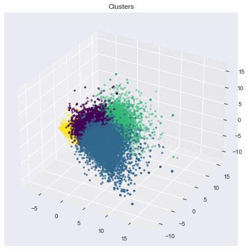

```python
fig = plt.figure()
ax = Axes3D(fig)

ax.scatter(users_with_label[0], users_with_label[1], users_with_label[2], c=users_with_label['label'].to_numpy(), cmap='viridis', s=10)
_ = plt.title('Clusters')
```

```python
print('Cluster ID     Number of users in cluster')
for idx, val in (pd.get_dummies(users_with_label['label'])).sum().iteritems():
    print(f'{idx}              {val}')
```

```
Cluster ID     Number of users in cluster
0              49142
1              19300
2              28405
3              11402
```

```python
# scores
score = pd.read_csv('database/hito3/score.csv', index_col=0)
score_user = score.join(users_with_label[['label']], on='user_id')
# groups
groups = (score_user[['anime_id', 'my_score', 'label']]
          .groupby(by=['label', 'anime_id'])
          .my_score.agg(['mean', 'count']))
groups['obj'] = groups['mean']*groups['count']
groups_obj = groups[['obj']].dropna()
# top 25
anime_cleaned = pd.read_csv('database/anime_cleaned.csv')
anime = anime_cleaned[['anime_id', 'title', 'genre', 'type', 'episodes', 'score', 'members']]
cats = groups_obj.index.get_level_values(0).unique().tolist()
rec = []
for cat in cats:
    rec.append(
        groups_obj
        .loc[cat]
        .sort_values(by='obj', ascending=False)
        .reset_index()
        .join(
            anime[['title', 'anime_id']].set_index('anime_id'),
            on='anime_id')
        ['title']
        .rename(cat)
    )
rec = pd.concat(rec, axis=1)
rec.head(25)
```

|  | 0 | 1 | 2 | 3 |
| --- | --- | --- | --- | --- |
| 0 | Death Note | Death Note | Toradora! | Death Note |
| 1 | Code Geass: Hangyaku no Lelouch | Naruto | Angel Beats! | Code Geass: Hangyaku no Lelouch |
| 2 | Sen to Chihiro no Kamikakushi | Fullmetal Alchemist | Clannad | Angel Beats! |
| 3 | Shingeki no Kyojin | Fullmetal Alchemist: Brotherhood | Death Note | Fullmetal Alchemist: Brotherhood |
| 4 | Code Geass: Hangyaku no Lelouch R2 | Dragon Ball Z | Sword Art Online | Code Geass: Hangyaku no Lelouch R2 |
| 5 | Fullmetal Alchemist: Brotherhood | Code Geass: Hangyaku no Lelouch | Clannad: After Story | Elfen Lied |
| 6 | Steins;Gate | Shingeki no Kyojin | Shingeki no Kyojin | Shingeki no Kyojin |
| 7 | Elfen Lied | Code Geass: Hangyaku no Lelouch R2 | Kaichou wa Maid-sama! | Toradora! |
| 8 | Angel Beats! | Dragon Ball | Zero no Tsukaima | Sword Art Online |
| 9 | Toradora! | Sen to Chihiro no Kamikakushi | Ouran Koukou Host Club | Steins;Gate |
| 10 | Tengen Toppa Gurren Lagann | Sword Art Online | Suzumiya Haruhi no Yuuutsu | Clannad |
| 11 | Fullmetal Alchemist | Elfen Lied | Elfen Lied | Fullmetal Alchemist |
| 12 | Sword Art Online | Tengen Toppa Gurren Lagann | Code Geass: Hangyaku no Lelouch | Naruto |
| 13 | Neon Genesis Evangelion | Soul Eater | K-On! | Sen to Chihiro no Kamikakushi |
| 14 | Suzumiya Haruhi no Yuuutsu | Cowboy Bebop | Ano Hi Mita Hana no Namae wo Bokutachi wa Mada... | Tengen Toppa Gurren Lagann |
| 15 | Howl no Ugoku Shiro | One Punch Man | Highschool of the Dead | Clannad: After Story |
| 16 | Durarara!! | Samurai Champloo | No Game No Life | Ouran Koukou Host Club |
| 17 | Mononoke Hime | Ao no Exorcist | Ore no Imouto ga Konnani Kawaii Wake ga Nai | Ano Hi Mita Hana no Namae wo Bokutachi wa Mada... |
| 18 | Mahou Shoujo Madoka★Magica | Mononoke Hime | Chuunibyou demo Koi ga Shitai! | Durarara!! |
| 19 | Clannad | Highschool of the Dead | Sakurasou no Pet na Kanojo | Mahou Shoujo Madoka★Magica |
| 20 | One Punch Man | Dragon Ball GT | Boku wa Tomodachi ga Sukunai | Bakemonogatari |
| 21 | Byousoku 5 Centimeter | Howl no Ugoku Shiro | Sen to Chihiro no Kamikakushi | Suzumiya Haruhi no Yuuutsu |
| 22 | Bakemonogatari | Bleach | Mirai Nikki (TV) | Kimi no Na wa. |
| 23 | Toki wo Kakeru Shoujo | Hellsing | Code Geass: Hangyaku no Lelouch R2 | Ao no Exorcist |
| 24 | Cowboy Bebop | Fullmetal Alchemist: The Conqueror of Shamballa | Zero no Tsukaima: Futatsuki no Kishi | Neon Genesis Evangelion |

Anteriormente no dejamos muy claro si estos resultados tienen sentido o no. A nuestro parecer, viniendo de gente que consume anime y que ha formado parte de comunidades de anime, podemos decir que sí, estos clusters son coherentes con los gustos de ciertas sub-comunidades conocidas que hay dentro del [fandom](https://en.wikipedia.org/wiki/Fandom) del anime.

¿Pero podemos mostrar esto empíricamente? Por suerte, hay al menos 2 consumidores de anime en el grupo. Nuestro experimento ahora consiste en ver estos clusters, seleccionar aquel que contenga uno o más de los animes favoritos del sujeto, y generar **sub-clusters** de éste cluster. Luego, ver el top 25 de animes de este sub-cluster, y repetir el proceso.

A priori, solo nos preocupamos de que el cluster contenga el anime favorito deñ sujeto, y que en cada iteración, este anime suba en el ranking. Veremos que solo concentrandonos en esto, otros animes que no son favoritos del sujeto, empesarán a aparecer en el top 25. En efecto, se logrará un "fine-tuning" de los gustos del sujeto.

### Sujeto: Iván

El anime favorito de Iván, es [K-On!](https://myanimelist.net/anime/5680/K-On?q=k-on&cat=anime) (técnicamente es [K-On!!](https://myanimelist.net/anime/7791/K-On), la segunda temporada, pero veremos que este aprecerá solo). K-On! es un anime popular, y por lo tanto aparece en el cluster 2, puesto 13. Entonces, hagamos clustering del cluster 2:

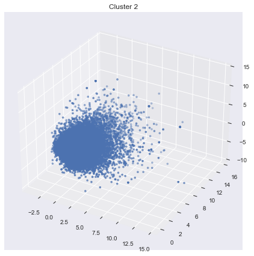

```python
# Now let's try to find sub-clusters in each cluster
# since k-means is working fine, let's keep using it

# let's test with cluster 0
cluster = 2
cluster2 = users_with_label[users_with_label['label'] == cluster]
cluster2 = cluster2.drop(columns=['label'])
# let's plot it to see it
fig = plt.figure()
ax = Axes3D(fig)
ax.scatter(cluster2[0], cluster2[1], cluster2[2], cmap='viridis', s=10)
_ = plt.title(f'Cluster {cluster}')
```

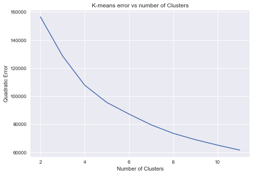

```python
# Now, let's find sub-clusters
inertia = []
scores = []
for n_clusters in range(2, 12):
    kmeans = KMeans(n_clusters=n_clusters)
    kmeans.fit(cluster2)
    inertia.append(kmeans.inertia_)
plt.plot(range(2, 12), inertia)
plt.xlabel('Number of Clusters')
plt.ylabel('Quadratic Error')
plt.grid(True)
_ = plt.title('K-means error vs number of Clusters')
```

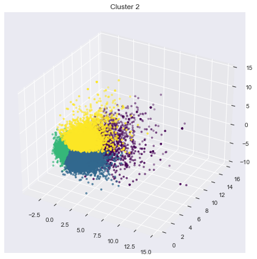

```python
# 4 seems good
kmeans = KMeans(n_clusters=4)
cluster2['sub_label'] = kmeans.fit_predict(cluster2)
# plot
fig = plt.figure()
ax = Axes3D(fig)
ax.scatter(cluster2[0], cluster2[1], cluster2[2], c=cluster2['sub_label'].to_numpy(), cmap='viridis', s=10)
_ = plt.title(f'Cluster {cluster}')
```

```python
# let's get the new scores for the users in cluster 0
score_user0 = score_user[score_user['label'] == cluster]
score_user0 = score_user0.join(cluster2[['sub_label']], on='user_id')
# let's get the new groups
groups2 = (score_user0[['anime_id', 'my_score', 'sub_label']]
            .groupby(by=['sub_label', 'anime_id'])
            .my_score.agg(['mean', 'count']))
groups2['obj'] = groups2['mean']*groups2['count']
groups2_obj = groups2[['obj']].dropna()
# now the new top 25's for these users!
cats = groups2_obj.index.get_level_values(0).unique().tolist()
rec0 = []
for cat in cats:
    rec0.append(
        groups2_obj
        .loc[cat]
        .sort_values(by='obj', ascending=False)
        .reset_index()
        .join(
            anime[['title', 'anime_id']].set_index('anime_id'),
            on='anime_id')
        ['title']
        .rename(cat)
    )
rec0 = pd.concat(rec0, axis=1)
rec0.head(25)
```

|  | 0 | 1 | 2 | 3 |
| --- | --- | --- | --- | --- |
| 0 | Toradora! | Toradora! | Toradora! | Ouran Koukou Host Club |
| 1 | Clannad | Sword Art Online | Angel Beats! | Death Note |
| 2 | Ouran Koukou Host Club | Death Note | Clannad | Clannad |
| 3 | Zero no Tsukaima | Angel Beats! | Clannad: After Story | Vampire Knight |
| 4 | Kaichou wa Maid-sama! | Shingeki no Kyojin | Sword Art Online | Toradora! |
| 5 | Rosario to Vampire | Zero no Tsukaima | Death Note | Clannad: After Story |
| 6 | Clannad: After Story | Code Geass: Hangyaku no Lelouch | K-On! | Sen to Chihiro no Kamikakushi |
| 7 | Angel Beats! | Naruto | Ano Hi Mita Hana no Namae wo Bokutachi wa Mada... | Fruits Basket |
| 8 | Zero no Tsukaima: Futatsuki no Kishi | Clannad | Ore no Imouto ga Konnani Kawaii Wake ga Nai | Vampire Knight: Guilty |
| 9 | Sword Art Online | Highschool of the Dead | Shingeki no Kyojin | Kimi ni Todoke |
| 10 | Boku wa Tomodachi ga Sukunai | No Game No Life | Chuunibyou demo Koi ga Shitai! | Elfen Lied |
| 11 | High School DxD | Code Geass: Hangyaku no Lelouch R2 | Suzumiya Haruhi no Yuuutsu | Lovely★Complex |
| 12 | Sakurasou no Pet na Kanojo | Elfen Lied | Sakurasou no Pet na Kanojo | Kaichou wa Maid-sama! |
| 13 | To LOVE-Ru | Fullmetal Alchemist: Brotherhood | No Game No Life | Howl no Ugoku Shiro |
| 14 | Ore no Imouto ga Konnani Kawaii Wake ga Nai | High School DxD | Kaichou wa Maid-sama! | Angel Beats! |
| 15 | Zero no Tsukaima: Princesses no Rondo | Zero no Tsukaima: Futatsuki no Kishi | Boku wa Tomodachi ga Sukunai | Byousoku 5 Centimeter |
| 16 | Rosario to Vampire Capu2 | Rosario to Vampire | Bakemonogatari | Suzumiya Haruhi no Yuuutsu |
| 17 | Baka to Test to Shoukanjuu | Clannad: After Story | Yahari Ore no Seishun Love Comedy wa Machigatt... | Special A |
| 18 | K-On! | Ao no Exorcist | Steins;Gate | Code Geass: Hangyaku no Lelouch |
| 19 | Kiss x Sis (TV) | Kaichou wa Maid-sama! | Mirai Nikki (TV) | Itazura na Kiss |
| 20 | Special A | Mirai Nikki (TV) | Sen to Chihiro no Kamikakushi | Chobits |
| 21 | Chuunibyou demo Koi ga Shitai! | Fullmetal Alchemist | Tonari no Kaibutsu-kun | Nana |
| 22 | Suzumiya Haruhi no Yuuutsu | Boku wa Tomodachi ga Sukunai | Elfen Lied | Air |
| 23 | Kami nomi zo Shiru Sekai | Hataraku Maou-sama! | Highschool of the Dead | Skip Beat! |
| 24 | Date A Live | Zero no Tsukaima: Princesses no Rondo | Hataraku Maou-sama! | Bokura ga Ita |

Cosas importantes que notar sobre el estado actual de los clusters: Animes como [Naruto](https://myanimelist.net/anime/20/Naruto?q=naruto&cat=anime), y otros pertenecientes al [Shonen](https://es.wikipedia.org/wiki/Shōnen), bajaron mucho en popularidad. En su lugar vemos más animes como Toradora, pertenecientes al Moe, ocupando los puestos más altos (K-On! también pertenece a la subcultura Moe).

Más aún, animes como [Sword Art Online](https://myanimelist.net/anime/11757/Sword_Art_Online), [Angel Beats!](https://myanimelist.net/anime/6547/Angel_Beats?q=angel%20beats&cat=anime) y [Chuunibyou demo Koi ga Shitai!](https://myanimelist.net/anime/14741/Chuunibyou_demo_Koi_ga_Shitai?q=chuun&cat=anime) están empezando a dominar, especialmente en el cluster 2. ¿Por qué esto es reelevante? Porque estos también son algunos de los animes favoritos de Iván.

Además podemos ver que K-On ahora aparece en más clusters y en mejores posiciones, en particular, su punto más alto hasta ahora es en el cluster 2. Por lo tanto **iremos más profundo** por ese camino:

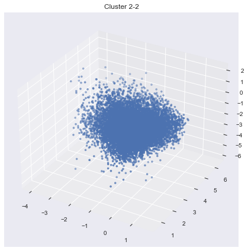

```python
# sub-sub-cluster 2-2 seems interesting
# let's go deeper
cluster = 2
cluster2_2 = cluster2[cluster2['sub_label'] == cluster]
cluster2_2 = cluster2_2.drop(columns=['sub_label'])
# let's plot it to see it
fig = plt.figure()
ax = Axes3D(fig)
ax.scatter(cluster2_2[0], cluster2_2[1], cluster2_2[2], cmap='viridis', s=10)
_ = plt.title(f'Cluster 2-{cluster}')
```

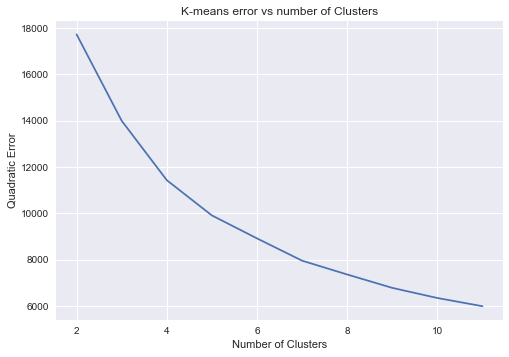

```python
# elbow
inertia = []
scores = []
for n_clusters in range(2, 12):
    kmeans = KMeans(n_clusters=n_clusters)
    kmeans.fit(cluster2_2)
    inertia.append(kmeans.inertia_)
plt.plot(range(2, 12), inertia)
plt.xlabel('Number of Clusters')
plt.ylabel('Quadratic Error')
plt.grid(True)
_ = plt.title('K-means error vs number of Clusters')
```

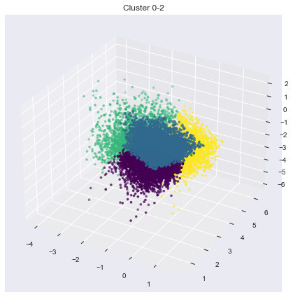

```python
# let's try 4
kmeans = KMeans(n_clusters=4)
cluster2_2['subsub_label'] = kmeans.fit_predict(cluster2_2)
# plot
fig = plt.figure()
ax = Axes3D(fig)
ax.scatter(cluster2_2[0], cluster2_2[1], cluster2_2[2], c=cluster2_2['subsub_label'].to_numpy(), cmap='viridis', s=10)
_ = plt.title(f'Cluster 0-{cluster}')
```

```python
# new scores
score_user2_2 = score_user0[score_user0['sub_label'] == cluster]
cluster2_2.head()
score_user2_2 = score_user2_2.join(cluster2_2[['subsub_label']], on='user_id')
# new groups
groups2_2 = (score_user2_2[['anime_id', 'my_score', 'subsub_label']]
            .groupby(by=['subsub_label', 'anime_id'])
            .my_score.agg(['mean', 'count']))
groups2_2['obj'] = groups2_2['mean']*groups2_2['count']
groups2_2_obj = groups2_2[['obj']].dropna()
# the new top 25's for these users!
cats = groups2_2_obj.index.get_level_values(0).unique().tolist()
rec0_3 = []
for cat in cats:
    rec0_3.append(
        groups2_2_obj
        .loc[cat]
        .sort_values(by='obj', ascending=False)
        .reset_index()
        .join(
            anime[['title', 'anime_id']].set_index('anime_id'),
            on='anime_id')
        ['title']
        .rename(cat)
    )
rec0_3 = pd.concat(rec0_3, axis=1)
rec0_3.head(25)
```

|  | 0 | 1 | 2 | 3 |
| --- | --- | --- | --- | --- |
| 0 | Toradora! | Toradora! | Toradora! | Toradora! |
| 1 | Angel Beats! | Death Note | K-On! | Angel Beats! |
| 2 | Sword Art Online | Clannad | Clannad | Sword Art Online |
| 3 | No Game No Life | Angel Beats! | Clannad: After Story | Clannad |
| 4 | Chuunibyou demo Koi ga Shitai! | Clannad: After Story | Angel Beats! | Ore no Imouto ga Konnani Kawaii Wake ga Nai |
| 5 | Ore no Imouto ga Konnani Kawaii Wake ga Nai | Ano Hi Mita Hana no Namae wo Bokutachi wa Mada... | Ano Hi Mita Hana no Namae wo Bokutachi wa Mada... | Boku wa Tomodachi ga Sukunai |
| 6 | Shingeki no Kyojin | Sen to Chihiro no Kamikakushi | Ore no Imouto ga Konnani Kawaii Wake ga Nai | Chuunibyou demo Koi ga Shitai! |
| 7 | Clannad | Shingeki no Kyojin | Suzumiya Haruhi no Yuuutsu | K-On! |
| 8 | Boku wa Tomodachi ga Sukunai | Sword Art Online | Chuunibyou demo Koi ga Shitai! | Sakurasou no Pet na Kanojo |
| 9 | Sakurasou no Pet na Kanojo | Ouran Koukou Host Club | K-On!! | Clannad: After Story |
| 10 | K-On! | Suzumiya Haruhi no Yuuutsu | Mahou Shoujo Madoka★Magica | Yahari Ore no Seishun Love Comedy wa Machigatt... |
| 11 | Bakemonogatari | Elfen Lied | Lucky☆Star | No Game No Life |
| 12 | Death Note | Kaichou wa Maid-sama! | Ouran Koukou Host Club | Kaichou wa Maid-sama! |
| 13 | Yahari Ore no Seishun Love Comedy wa Machigatt... | K-On! | Death Note | Baka to Test to Shoukanjuu |
| 14 | Hataraku Maou-sama! | Kimi ni Todoke | Kaichou wa Maid-sama! | Zero no Tsukaima |
| 15 | Steins;Gate | Code Geass: Hangyaku no Lelouch | Sen to Chihiro no Kamikakushi | Ano Hi Mita Hana no Namae wo Bokutachi wa Mada... |
| 16 | Clannad: After Story | Byousoku 5 Centimeter | Sakurasou no Pet na Kanojo | High School DxD |
| 17 | Ano Hi Mita Hana no Namae wo Bokutachi wa Mada... | Another | Kimi ni Todoke | Kami nomi zo Shiru Sekai |
| 18 | One Punch Man | Steins;Gate | Sword Art Online | Hataraku Maou-sama! |
| 19 | Highschool of the Dead | Tonari no Kaibutsu-kun | Byousoku 5 Centimeter | Suzumiya Haruhi no Yuuutsu |
| 20 | Suzumiya Haruhi no Yuuutsu | Code Geass: Hangyaku no Lelouch R2 | Boku wa Tomodachi ga Sukunai | Boku wa Tomodachi ga Sukunai Next |
| 21 | Baka to Test to Shoukanjuu | Mirai Nikki (TV) | Yahari Ore no Seishun Love Comedy wa Machigatt... | Nisekoi |
| 22 | Kami nomi zo Shiru Sekai | Toki wo Kakeru Shoujo | Kimi no Na wa. | Shingeki no Kyojin |
| 23 | Zero no Tsukaima | Lovely★Complex | Tonari no Kaibutsu-kun | Bakemonogatari |
| 24 | Kore wa Zombie Desu ka? | Howl no Ugoku Shiro | Gekkan Shoujo Nozaki-kun | Tonari no Kaibutsu-kun |

Ahora solo basta con notar el cluster 2 (sí, es una coincidencia que todos los clusters hasta ahora hayan sido 2->2->2. Los índices de los cluster son random, cada vez que corremos esto cambian de nombre):

### Sujeto: Álvaro

Para convencernos de que esto funciona bien, haremos lo mismo pero con Álvaro. Su anime favorito es [Neon Genesis Evangelion](https://myanimelist.net/anime/30/Neon_Genesis_Evangelion) -> cluster 0 de los clusters generados al principio.

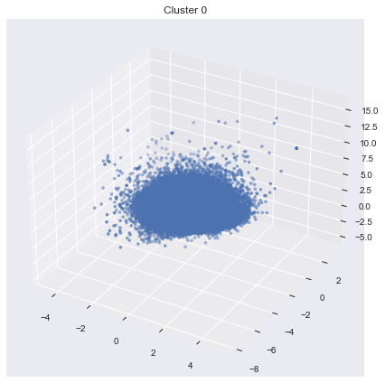

```python
# starting over from cluster 0
cluster = 0
cluster0 = users_with_label[users_with_label['label'] == cluster]
cluster0 = cluster0.drop(columns=['label'])
# let's plot it to see it
fig = plt.figure()
ax = Axes3D(fig)
ax.scatter(cluster0[0], cluster0[1], cluster0[2], cmap='viridis', s=10)
_ = plt.title(f'Cluster {cluster}')
```

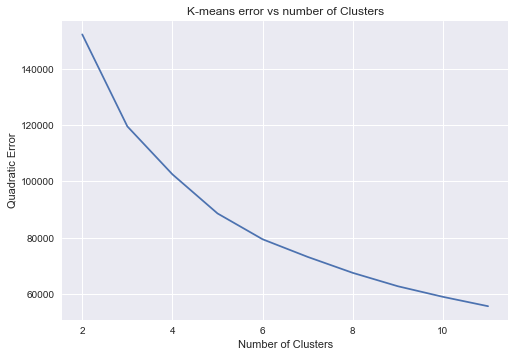

```python
# elbow
inertia = []
scores = []
for n_clusters in range(2, 12):
    kmeans = KMeans(n_clusters=n_clusters)
    kmeans.fit(cluster0)
    inertia.append(kmeans.inertia_)
plt.plot(range(2, 12), inertia)
plt.xlabel('Number of Clusters')
plt.ylabel('Quadratic Error')
plt.grid(True)
_ = plt.title('K-means error vs number of Clusters')
```

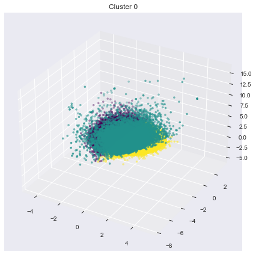

```python
# 3 looks good
kmeans = KMeans(n_clusters=3)
cluster0['sub_label'] = kmeans.fit_predict(cluster0)
# plot
fig = plt.figure()
ax = Axes3D(fig)
ax.scatter(cluster0[0], cluster0[1], cluster0[2], c=cluster0['sub_label'].to_numpy(), cmap='viridis', s=10)
_ = plt.title(f'Cluster {cluster}')
```

```python
# new scores
score_user0 = score_user[score_user['label'] == cluster]
score_user0 = score_user0.join(cluster0[['sub_label']], on='user_id')
# new groups
groups0 = (score_user0[['anime_id', 'my_score', 'sub_label']]
            .groupby(by=['sub_label', 'anime_id'])
            .my_score.agg(['mean', 'count']))
groups0['obj'] = groups0['mean']*groups0['count']
groups0_obj = groups0[['obj']].dropna()
# the new top 25's for these users!
cats = groups0_obj.index.get_level_values(0).unique().tolist()
rec4 = []
for cat in cats:
    rec4.append(
        groups0_obj
        .loc[cat]
        .sort_values(by='obj', ascending=False)
        .reset_index()
        .join(
            anime[['title', 'anime_id']].set_index('anime_id'),
            on='anime_id')
        ['title']
        .rename(cat)
    )
rec4 = pd.concat(rec4, axis=1)
rec4.head(25)
```

|  | 0 | 1 | 2 |
| --- | --- | --- | --- |
| 0 | Death Note | Death Note | Death Note |
| 1 | Sen to Chihiro no Kamikakushi | Sen to Chihiro no Kamikakushi | Code Geass: Hangyaku no Lelouch |
| 2 | Steins;Gate | Code Geass: Hangyaku no Lelouch | Shingeki no Kyojin |
| 3 | Code Geass: Hangyaku no Lelouch | Elfen Lied | Fullmetal Alchemist: Brotherhood |
| 4 | Shingeki no Kyojin | Neon Genesis Evangelion | Code Geass: Hangyaku no Lelouch R2 |
| 5 | Toradora! | Code Geass: Hangyaku no Lelouch R2 | Angel Beats! |
| 6 | Angel Beats! | Mononoke Hime | Sword Art Online |
| 7 | Mahou Shoujo Madoka★Magica | Cowboy Bebop | Sen to Chihiro no Kamikakushi |
| 8 | Fullmetal Alchemist: Brotherhood | Howl no Ugoku Shiro | Steins;Gate |
| 9 | Code Geass: Hangyaku no Lelouch R2 | Ghost in the Shell | Toradora! |
| 10 | Suzumiya Haruhi no Yuuutsu | Fullmetal Alchemist | Elfen Lied |
| 11 | Ano Hi Mita Hana no Namae wo Bokutachi wa Mada... | Fullmetal Alchemist: Brotherhood | Fullmetal Alchemist |
| 12 | Bakemonogatari | Shingeki no Kyojin | Tengen Toppa Gurren Lagann |
| 13 | Clannad | Tengen Toppa Gurren Lagann | Naruto |
| 14 | Elfen Lied | Toki wo Kakeru Shoujo | One Punch Man |
| 15 | Durarara!! | Steins;Gate | Durarara!! |
| 16 | Byousoku 5 Centimeter | Neon Genesis Evangelion: The End of Evangelion | No Game No Life |
| 17 | Clannad: After Story | Byousoku 5 Centimeter | Highschool of the Dead |
| 18 | Toki wo Kakeru Shoujo | Akira | Mirai Nikki (TV) |
| 19 | Howl no Ugoku Shiro | Darker than Black: Kuro no Keiyakusha | Clannad |
| 20 | Tengen Toppa Gurren Lagann | Samurai Champloo | Ao no Exorcist |
| 21 | Neon Genesis Evangelion | Suzumiya Haruhi no Yuuutsu | Suzumiya Haruhi no Yuuutsu |
| 22 | Mononoke Hime | FLCL | Tokyo Ghoul |
| 23 | Sword Art Online | Baccano! | Soul Eater |
| 24 | K-On! | Higurashi no Naku Koro ni | Another |

La aparición de FLCL es interesante, ya que no tiene muchas similitudes superficiales con el resto, como géneros y cosas así, sino que los temas que su trama toca son similares (Coloquialmente, se diría que tiene una **vibra** similar a los otros). En el círculo de fanáticos de éstos animes, FLCL suele ser popular, así que es natural que aparezca en el cluster 1.

Ya no es necesario ir más profundo que ésto.

Sería bueno que este proceso sea automático. En el sentido de que, a un usuario se le pueda mostrar la tabla de los clusters iniciales, eliga una con animes que reconozca y le gusten, y que se genere automáticamente los sub-clusters de ese cluster, y luego se repita el proceso, digamos unas 4 o 5 veces, o hasta que el usuario esté satisfecho.

Todo es automatizable, excepto por el método del codo. Es la única parte hasta ahora que requiere intervención humana. Alguien tiene que ver el gráfico y decidir cuántos clusters hay.

Por suerte, encontramos un algoritmo que hace el métodod el codo automáticamente: [AutoElbow](https://pypi.org/project/autoelbow/).

Con esto instalado, ¡podemos automatizar este proceso! Tomemos como ejemplo los gustos de Iván:

```python
from autoelbow_rupakbob import autoelbow

print("Clusters originales óptimos:", autoelbow.auto_elbow_search(users_with_label), end=", ")
print("Para los sub-clusters de cluster2:", autoelbow.auto_elbow_search(cluster2), end=", ")
print("Sub-clusters de ese:", autoelbow.auto_elbow_search(cluster2_2), end= ", ")
print("Sub-clusters de cluster0:", autoelbow.auto_elbow_search(cluster0))
print("Silhouette Scores:")
print("Clusters originales:", silhouette_score(users_with_label, users_with_label['label']), end=", ")
print("Para los sub-clusters de cluster2:", silhouette_score(cluster2, cluster2['sub_label']), end=", ")
print("Sub-clusters de ese:", silhouette_score(cluster2_2, cluster2_2['subsub_label']), end= ", ")
print("Sub-clusters de cluster0:", silhouette_score(cluster0, cluster0['sub_label']))
```

```
Clusters originales óptimos: 4, Para los sub-clusters de cluster2: 4, Sub-clusters de ese: 4, Sub-clusters de cluster0: 3
Silhouette Scores:
Clusters originales: 0.3660354625952371, Para los sub-clusters de cluster2: 0.3016760987937989, Sub-clusters de ese: 0.42003495635461063, Sub-clusters de cluster0: 0.3857786856845514
```

Es por ésto que cambiamos de 6 a 4 clusters en el clustering original. Este algoritmo nos ayudó a decidir cuántos clusters hay. Ya que hay momentos en que el gráfico no tiene un codo claro.

En cuanto a implementar un clustering automático, para recomendaciones automáticas, esto se escapa del alcance del experimento, además ya llevamos mucho espacio en ésto, así que solo lo dejaremos en que es posible, y los resultados serían bastante precisos.

## Experimento 2:

### ¿Existe alguna relación entre las características de un usuario y la puntuación que le pone a ciertos animes o géneros?

Ya que tenemos estos clusters, podemos checkear esto brevemente. Bastará con ver a los usuarios de los clusters originales que generamos más arriba:

```python
# let's see the gender, location and age of each cluster
cluster0 = users_with_label[users_with_label['label'] == 0]
cluster1 = users_with_label[users_with_label['label'] == 1]
cluster2 = users_with_label[users_with_label['label'] == 2]
cluster3 = users_with_label[users_with_label['label'] == 3]
```

```python
users_cleaned = pd.read_csv('database/users_cleaned.csv')
users_cleaned['age'] = pd.to_datetime('today').year - pd.to_datetime(users_cleaned['birth_date']).dt.year
```

Se suele decir que ciertos anime son populares con ciertos grupos de personas identificadas por género, país y edad. i.e: Los animes del género Shonen son populares con hombres jóvenes, los anime del género Shoujo con mujeres jóvenes, [Dragon Ball Z](https://myanimelist.net/anime/813/Dragon_Ball_Z) es muy popular con Latinoamérica y especialmente Brazil, etc.

Identificar este tipo de correlaciones para cada anime puede ser algo muy útil a la hora de recomendar animes. Veremos que en efecto, estos clusters son representativos de una relación entre caracteristicas de los usuarios que los componen, y los animes que ven. Ocuparemos las mismas estadísticas que ocupamos en el Hito 1 para ver características de todos los usuarios del dataset. Como tal, nos referiremos a esos resultados en este experimento:

```
Promedio de edad cluster 0:  29.418611793611795
Mediana de edad cluster 0:  29.0
```

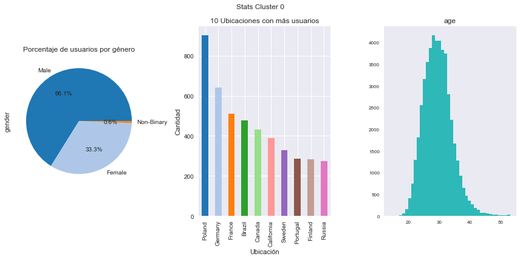

```python
# cluster 0
gender0 = users_cleaned[users_cleaned['user_id'].isin(cluster0.index)]['gender'].value_counts()
locations0 = users_cleaned[users_cleaned['user_id'].isin(cluster0.index)]['location'].value_counts()
print("Promedio de edad cluster 0: ", users_cleaned[users_cleaned['user_id'].isin(cluster0.index)]['age'].mean())
print("Mediana de edad cluster 0: ", users_cleaned[users_cleaned['user_id'].isin(cluster0.index)]['age'].median())
# plots
colormap = plt.cm.tab20
colors = [colormap(i) for i in np.linspace(0.0, 1.0, 15)]
fig, (ax1,ax2,ax3) = plt.subplots(1,3, figsize=(15,6))
gender0.plot(kind='pie', autopct='%1.1f%%', figsize=(6, 6), title="Porcentaje de usuarios por género", ax=ax1, colors = colors)
locations0.head(10).plot(kind='bar', xlabel="Ubicación", ylabel="Cantidad", title="10 Ubicaciones con más usuarios", figsize=(12, 6), ax=ax2, color = colors)
users_cleaned[users_cleaned['user_id'].isin(cluster0.index)].hist(column='age', bins=40, xlabelsize=8, ylabelsize=8, figsize=(12, 6), color='#2EB8B8', grid=False, ax=ax3)
fig.suptitle('Stats Cluster 0')
plt.tight_layout()
```

El Cluster 0 no es muy interesante. Sus estadisticas son muy parecidas a las estadísticas de todos los usuarios. Esto podría ser porque el cluster 0 abarca animes que son populares independiente del género de sus usuarios, pais y edad. Tal vez si analizaramos sus sub-clusters encontraríamos cosas más interesantes.

```
Promedio de edad cluster 1:  29.70403681238235
Mediana de edad cluster 1:  30.0
```

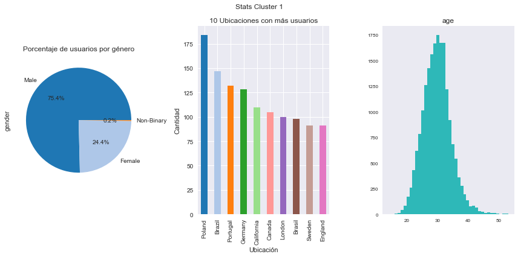

```python
# cluster 1
gender1 = users_cleaned[users_cleaned['user_id'].isin(cluster1.index)]['gender'].value_counts()
locations1 = users_cleaned[users_cleaned['user_id'].isin(cluster1.index)]['location'].value_counts()
print("Promedio de edad cluster 1: ", users_cleaned[users_cleaned['user_id'].isin(cluster1.index)]['age'].mean())
print("Mediana de edad cluster 1: ", users_cleaned[users_cleaned['user_id'].isin(cluster1.index)]['age'].median())
# plots
colormap = plt.cm.tab20
colors = [colormap(i) for i in np.linspace(0.0, 1.0, 15)]
fig, (ax1,ax2,ax3) = plt.subplots(1,3, figsize=(15,6))
gender1.plot(kind='pie', autopct='%1.1f%%', figsize=(6, 6), title="Porcentaje de usuarios por género", ax=ax1, colors = colors)
locations1.head(10).plot(kind='bar', xlabel="Ubicación", ylabel="Cantidad", title="10 Ubicaciones con más usuarios", figsize=(12, 6), ax=ax2, color = colors)
users_cleaned[users_cleaned['user_id'].isin(cluster1.index)].hist(column='age', bins=40, xlabelsize=8, ylabelsize=8, figsize=(12, 6), color='#2EB8B8', grid=False, ax=ax3)
fig.suptitle('Stats Cluster 1')
plt.tight_layout()
```

Hay 2 cosas interesantes del cluster 1: Primero, la proporción de mujeres bajó mucho con respecto al total. Segundo, Brazil subió al segundo puesto.

Recordemos que los animes más populares de este cluster son Shonens. Dragon Ball Z, Naruto, Fullmetal Alchemist, etc. Existen 2 estereotipos sobre este tipo de anime. El primero es que este tipo de anime de acción y peleas es mucho más popular entre personas de género masculino. El segundo es que este tipo de anime es muy popular en latinoamérica, y especialmente en Brazil. Parece ser que los datos apoyan estos estereotipos.

```
Promedio de edad cluster 2:  28.241993005782348
Mediana de edad cluster 2:  28.0
```

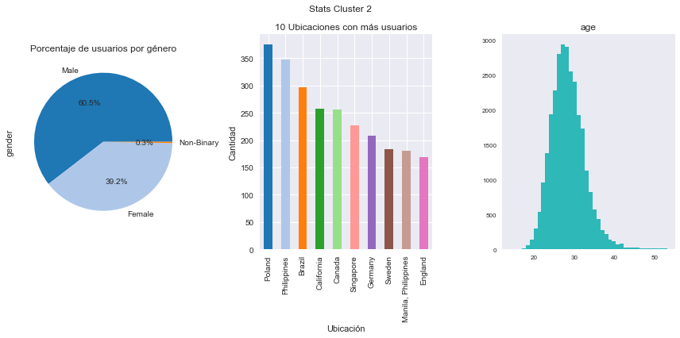

```python
# cluster 2
gender2 = users_cleaned[users_cleaned['user_id'].isin(cluster2.index)]['gender'].value_counts()
locations2 = users_cleaned[users_cleaned['user_id'].isin(cluster2.index)]['location'].value_counts()
print("Promedio de edad cluster 2: ", users_cleaned[users_cleaned['user_id'].isin(cluster2.index)]['age'].mean())
print("Mediana de edad cluster 2: ", users_cleaned[users_cleaned['user_id'].isin(cluster2.index)]['age'].median())
# plots
colormap = plt.cm.tab20
colors = [colormap(i) for i in np.linspace(0.0, 1.0, 15)]
fig, (ax1,ax2,ax3) = plt.subplots(1,3, figsize=(15,6))
gender2.plot(kind='pie', autopct='%1.1f%%', figsize=(6, 6), title="Porcentaje de usuarios por género", ax=ax1, colors = colors)
locations2.head(10).plot(kind='bar', xlabel="Ubicación", ylabel="Cantidad", title="10 Ubicaciones con más usuarios", figsize=(12, 6), ax=ax2, color = colors)
users_cleaned[users_cleaned['user_id'].isin(cluster2.index)].hist(column='age', bins=40, xlabelsize=8, ylabelsize=8, figsize=(12, 6), color='#2EB8B8', grid=False, ax=ax3)
fig.suptitle('Stats Cluster 2')
plt.tight_layout()
```

El cluster 2 resenta la edad promedio más baja entre los clusters, y muestra una proporción femenina de usuarios más grande. Los animes de este cluster incluyen animes relativamente más recientes (más o menos de los fines de la década del 2000 o principios de la del 2010), Lo que explicaría la edad promedio más baja.

La proporción más grande de mujeres incluso podría indicar que el anime se a vuelto más popular entre el público femenino a partir de ésta época, cosa que se ha especulado.

```
Promedio de edad cluster 3:  29.145036829182743
Mediana de edad cluster 3:  29.0
```

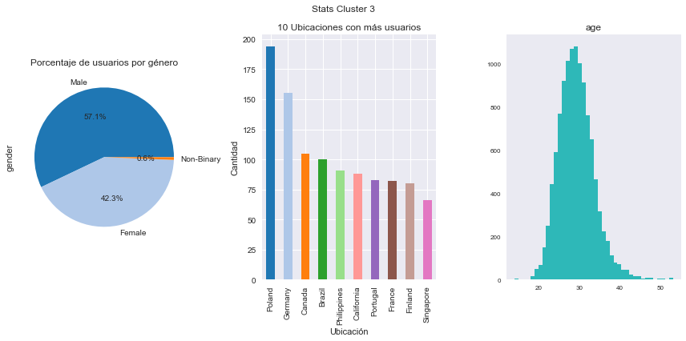

```python
# cluster 3
gender3 = users_cleaned[users_cleaned['user_id'].isin(cluster3.index)]['gender'].value_counts()
locations3 = users_cleaned[users_cleaned['user_id'].isin(cluster3.index)]['location'].value_counts()
print("Promedio de edad cluster 3: ", users_cleaned[users_cleaned['user_id'].isin(cluster3.index)]['age'].mean())
print("Mediana de edad cluster 3: ", users_cleaned[users_cleaned['user_id'].isin(cluster3.index)]['age'].median())
# plots
colormap = plt.cm.tab20
colors = [colormap(i) for i in np.linspace(0.0, 1.0, 15)]
fig, (ax1,ax2,ax3) = plt.subplots(1,3, figsize=(15,6))
gender3.plot(kind='pie', autopct='%1.1f%%', figsize=(6, 6), title="Porcentaje de usuarios por género", ax=ax1, colors = colors)
locations3.head(10).plot(kind='bar', xlabel="Ubicación", ylabel="Cantidad", title="10 Ubicaciones con más usuarios", figsize=(12, 6), ax=ax2, color = colors)
users_cleaned[users_cleaned['user_id'].isin(cluster3.index)].hist(column='age', bins=40, xlabelsize=8, ylabelsize=8, figsize=(12, 6), color='#2EB8B8', grid=False, ax=ax3)
fig.suptitle('Stats Cluster 3')
plt.tight_layout()
```

El cluster 3 tiene la poporción más alta de mujeres de todos los cluster. Coincidentalmente incluye animes como Code Geass, Clannad, Madoka Magica y Kimi no Na Wa, animes que, al menos en Japón, fueron notorios por atraer a un gran público femenino. Esto sugiere que estre trend se ha extendido a otros países.

Solo con ver los clusters más superficiales ya se pueden identificar caracteristicas claras de los usuarios que los componen. Dejan claro que hay relación entre las características de los usuarios y los animes que ven. Esto es algo que se podría aprovechar para hacer recomendaciones más precisas. Ciertos animes podrían ser marcados como "Popular en tal pais" o "Popular para cierto género", y se podrían ocupar estas etiquetas para hacer aún más "fine tuning" en las recomendaciones.

## Experimento 3

### ¿Se puede clasificar a los animes para poder predecir su popularidad o éxito?

Por último, ocuparemos técnicas de clasificaión para ver si es posible predecir si un anime será popular o no, en base a la data entregada por anime_cleaned.csv.

```python
anime = pd.read_csv('database/anime_cleaned.csv')
pd.set_option('display.max_columns', None)
anime.head(1)
```

|  | anime_id | title | title_english | title_japanese | title_synonyms | image_url | type | source | episodes | status | airing | aired_string | aired | duration | rating | score | scored_by | rank | popularity | members | favorites | background | premiered | broadcast | related | producer | licensor | studio | genre | … |
| --- | --- | --- | --- | --- | --- | --- | --- | --- | --- | --- | --- | --- | --- | --- | --- | --- | --- | --- | --- | --- | --- | --- | --- | --- | --- | --- | --- | --- | --- | --- |
| 0 | 11013 | Inu x Boku SS | Inu X Boku Secret Service | 妖狐×僕SS | Youko x Boku SS | https://myanimelist.cdn-dena.com/images/anime/... | TV | Manga | 12 | Finished Airing | False | Jan 13, 2012 to Mar 30, 2012 | {'from': '2012-01-13', 'to': '2012-03-30'} | 24 min. per ep. | PG-13 - Teens 13 or older | 7.63 | 139250 | 1274.0 | 231 | 283882 | 2809 | Inu x Boku SS was licensed by Sentai Filmworks... | Winter 2012 | Fridays at Unknown | {'Adaptation': [{'mal_id': 17207, 'type': 'man... | Aniplex, Square Enix, Mainichi Broadcasting Sy... | Sentai Filmworks | David Production | Comedy, Supernatural, Romance, Shounen | … |

De todos esos features, solo usaremos aquellos que son numéricos, o al menos fáciles de convertir a numéricos de una forma que tenga sentido. Pero más importante que eso, debemos ocupar features que tengan sentido para la popularidad. La fecha de emisión es irrelevante por ejemplo. Solo nos importará lo siguiente:

```python
df_anime = anime[['anime_id','source', 'type', 'genre' ,'episodes', 'rating', 'score', 'studio']]
df_anime = df_anime.join(df_anime['genre'].str.get_dummies(', '))
df_anime = df_anime.drop(columns=['genre'])

df_anime.head()
```

|  | anime_id | source | type | episodes | rating | score | studio | Action | Adventure | Cars | Comedy | Dementia | Demons | Drama | Ecchi | Fantasy | Game | Harem | Hentai | Historical | Horror | Josei | Kids | Magic | Martial Arts | Mecha | Military | Music | Mystery | … |
| --- | --- | --- | --- | --- | --- | --- | --- | --- | --- | --- | --- | --- | --- | --- | --- | --- | --- | --- | --- | --- | --- | --- | --- | --- | --- | --- | --- | --- | --- | --- |
| 0 | 11013 | Manga | TV | 12 | PG-13 - Teens 13 or older | 7.63 | David Production | 0 | 0 | 0 | 1 | 0 | 0 | 0 | 0 | 0 | 0 | 0 | 0 | 0 | 0 | 0 | 0 | 0 | 0 | 0 | 0 | 0 | 0 | … |
| 1 | 2104 | Manga | TV | 26 | PG-13 - Teens 13 or older | 7.89 | Gonzo | 0 | 0 | 0 | 1 | 0 | 0 | 0 | 0 | 0 | 0 | 0 | 0 | 0 | 0 | 0 | 0 | 0 | 0 | 0 | 0 | 0 | 0 | … |
| 2 | 5262 | Manga | TV | 51 | PG - Children | 7.55 | Satelight | 0 | 0 | 0 | 1 | 0 | 0 | 0 | 0 | 0 | 0 | 0 | 0 | 0 | 0 | 0 | 0 | 1 | 0 | 0 | 0 | 0 | 0 | … |
| 3 | 721 | Original | TV | 38 | PG-13 - Teens 13 or older | 8.21 | Hal Film Maker | 0 | 0 | 0 | 1 | 0 | 0 | 1 | 0 | 1 | 0 | 0 | 0 | 0 | 0 | 0 | 0 | 1 | 0 | 0 | 0 | 0 | 0 | … |
| 4 | 12365 | Manga | TV | 25 | PG-13 - Teens 13 or older | 8.67 | J.C.Staff | 0 | 0 | 0 | 1 | 0 | 0 | 1 | 0 | 0 | 0 | 0 | 0 | 0 | 0 | 0 | 0 | 0 | 0 | 0 | 0 | 0 | 0 | … |

Si el anime está basado en un manga u otra cosa, su tipo de emisión, cantidad de capítulos, rating, puntaje en MAL, estudio que lo produjo y por último, los géneros.

Ahora pasamos todo a datos numéricos que podemos ocupar para entrenar nuestro modelo:

```python
enconder = LabelEncoder()
source_labels = enconder.fit_transform(df_anime['source'])
source_mappings = {index: label for index, label in
 enumerate(enconder.classes_)}

type_labels = enconder.fit_transform(df_anime['type'])
type_mappings = {index: label for index, label in
 enumerate(enconder.classes_)}


rating_labels = enconder.fit_transform(df_anime['rating'])
rating_mappings = {index: label for index, label in
 enumerate(enconder.classes_)}

studio_labels = enconder.fit_transform(df_anime['studio'])
studio_mappings = {index: label for index, label in
 enumerate(enconder.classes_)}
```

```python
df_anime['source_label'] = source_labels
df_anime['type_label'] = type_labels
df_anime['rating_label'] = rating_labels
df_anime['studio_label'] = studio_labels
df_anime.head()
```

|  | anime_id | source | type | episodes | rating | score | studio | Action | Adventure | Cars | Comedy | Dementia | Demons | Drama | Ecchi | Fantasy | Game | Harem | Hentai | Historical | Horror | Josei | Kids | Magic | Martial Arts | Mecha | Military | Music | Mystery | … |
| --- | --- | --- | --- | --- | --- | --- | --- | --- | --- | --- | --- | --- | --- | --- | --- | --- | --- | --- | --- | --- | --- | --- | --- | --- | --- | --- | --- | --- | --- | --- |
| 0 | 11013 | Manga | TV | 12 | PG-13 - Teens 13 or older | 7.63 | David Production | 0 | 0 | 0 | 1 | 0 | 0 | 0 | 0 | 0 | 0 | 0 | 0 | 0 | 0 | 0 | 0 | 0 | 0 | 0 | 0 | 0 | 0 | … |
| 1 | 2104 | Manga | TV | 26 | PG-13 - Teens 13 or older | 7.89 | Gonzo | 0 | 0 | 0 | 1 | 0 | 0 | 0 | 0 | 0 | 0 | 0 | 0 | 0 | 0 | 0 | 0 | 0 | 0 | 0 | 0 | 0 | 0 | … |
| 2 | 5262 | Manga | TV | 51 | PG - Children | 7.55 | Satelight | 0 | 0 | 0 | 1 | 0 | 0 | 0 | 0 | 0 | 0 | 0 | 0 | 0 | 0 | 0 | 0 | 1 | 0 | 0 | 0 | 0 | 0 | … |
| 3 | 721 | Original | TV | 38 | PG-13 - Teens 13 or older | 8.21 | Hal Film Maker | 0 | 0 | 0 | 1 | 0 | 0 | 1 | 0 | 1 | 0 | 0 | 0 | 0 | 0 | 0 | 0 | 1 | 0 | 0 | 0 | 0 | 0 | … |
| 4 | 12365 | Manga | TV | 25 | PG-13 - Teens 13 or older | 8.67 | J.C.Staff | 0 | 0 | 0 | 1 | 0 | 0 | 1 | 0 | 0 | 0 | 0 | 0 | 0 | 0 | 0 | 0 | 0 | 0 | 0 | 0 | 0 | 0 | … |

¿Qué es un anime exitoso? Hay muchas formas de definir esto, y la verdad no hay una respuesta correcta. Depende de a quien se le pregunte. Necesitamos algo concreto pero razonable.

La clave para nosotros estará en el score. Desde cierto score hacia arriba consideraremos que un anime es exitoso. ¿Pero en dónde hacemos el corte? Analicemos la data:

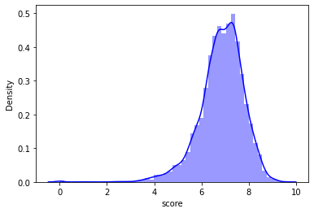

```python
sb.distplot(df_anime['score'], color='blue')
```

```python
df_anime.score.mean()
```

```
6.848998200359939
```

Vemos que el score promedio es de 6.8. Como por lo general se espera que un anime exitoso esté "por sobre el promedio", eligiremos un score de 7.0 como corte. Vale destacar que probamos con otros valores, pero éste nos termino dando una presición muy pareja en el modelo, además que es un valor bastante razonable.

```python
df_anime['exitoso'] = np.where(df_anime['score']>= 7, '1', '0')
df_anime.head()
```

|  | anime_id | source | type | episodes | rating | score | studio | Action | Adventure | Cars | Comedy | Dementia | Demons | Drama | Ecchi | Fantasy | Game | Harem | Hentai | Historical | Horror | Josei | Kids | Magic | Martial Arts | Mecha | Military | Music | Mystery | … |
| --- | --- | --- | --- | --- | --- | --- | --- | --- | --- | --- | --- | --- | --- | --- | --- | --- | --- | --- | --- | --- | --- | --- | --- | --- | --- | --- | --- | --- | --- | --- |
| 0 | 11013 | Manga | TV | 12 | PG-13 - Teens 13 or older | 7.63 | David Production | 0 | 0 | 0 | 1 | 0 | 0 | 0 | 0 | 0 | 0 | 0 | 0 | 0 | 0 | 0 | 0 | 0 | 0 | 0 | 0 | 0 | 0 | … |
| 1 | 2104 | Manga | TV | 26 | PG-13 - Teens 13 or older | 7.89 | Gonzo | 0 | 0 | 0 | 1 | 0 | 0 | 0 | 0 | 0 | 0 | 0 | 0 | 0 | 0 | 0 | 0 | 0 | 0 | 0 | 0 | 0 | 0 | … |
| 2 | 5262 | Manga | TV | 51 | PG - Children | 7.55 | Satelight | 0 | 0 | 0 | 1 | 0 | 0 | 0 | 0 | 0 | 0 | 0 | 0 | 0 | 0 | 0 | 0 | 1 | 0 | 0 | 0 | 0 | 0 | … |
| 3 | 721 | Original | TV | 38 | PG-13 - Teens 13 or older | 8.21 | Hal Film Maker | 0 | 0 | 0 | 1 | 0 | 0 | 1 | 0 | 1 | 0 | 0 | 0 | 0 | 0 | 0 | 0 | 1 | 0 | 0 | 0 | 0 | 0 | … |
| 4 | 12365 | Manga | TV | 25 | PG-13 - Teens 13 or older | 8.67 | J.C.Staff | 0 | 0 | 0 | 1 | 0 | 0 | 1 | 0 | 0 | 0 | 0 | 0 | 0 | 0 | 0 | 0 | 0 | 0 | 0 | 0 | 0 | 0 | … |

Ahora podemos comenzar con el training:

```python
X = df_anime[['source_label', 'type_label', 'episodes', 'rating_label', 'studio_label', 'Action', 'Adventure', 'Cars', 'Comedy', 'Dementia', 'Demons', 'Drama', 'Ecchi', 'Fantasy', 'Game', 'Harem', 'Hentai',
'Historical', 'Horror', 'Josei', 'Kids', 'Magic', 'Martial Arts', 'Mecha', 'Military', 'Mystery', 'Parody', 'Police',	'Psychological',
'Romance',	'Samurai', 'School', 'Sci-Fi', 'Seinen', 'Shoujo', 'Shoujo Ai',	'Shounen', 'Shounen Ai', 'Slice of Life', 'Space',	'Sports',
'Super Power',	'Supernatural',	'Thriller','Vampire', 'Yaoi','Yuri']]
y = df_anime['exitoso']

#TEST
X_train, X_test, y_train, y_test = train_test_split(X, y, test_size=0.3, random_state=1234, stratify=y)
```

```python
clf = DecisionTreeClassifier()
clf.fit(X_train, y_train)

y_pred = clf.predict(X_test)
```

```python
print(classification_report(y_test, y_pred))
```

```
              precision    recall  f1-score   support

           0       0.69      0.69      0.69      1056
           1       0.65      0.65      0.65       945

    accuracy                           0.67      2001
   macro avg       0.67      0.67      0.67      2001
weighted avg       0.67      0.67      0.67      2001
```

Como mencionamos antes, jugamos un poco con el score de corte, antes de llegar a 7.0. En el estado actual, obtenemos precision bastante pareja en el modelo para animes exitosos (1) y no exitosos (0). Dejar el score de corte más bajo, resultaba en mejor precisión para exitosos, y viceversa. En términos de support, esto tiene todo el sentido del mundo.

Nuestroi accuarcy termina siendo de 0.67, o más o menos 2/3. No parece muy bueno, pero al menos es mejor que lanzar una moneda. Sin embargo, veremos que aún así es bastante acertado.

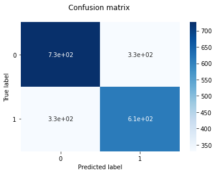

```python
# Compute confusion matrix. By default is not normalized (normalize=None)
# If necessary change 'y_pred' according to your variable name
cm = confusion_matrix(y_test, y_pred)

# Only use the labels that appear in the data
classes = unique_labels(y_test, y_pred)

data = pd.DataFrame(cm, index=classes, columns=classes)

g = sns.heatmap(data, annot=True, cmap="Blues")
g.set_yticklabels(g.get_yticklabels(), rotation=0)

plt.title('Confusion matrix \n')
plt.xlabel('Predicted label')
plt.ylabel('True label')

plt.autoscale()
```

Como hay más support para animes no exitosos, tiene sentido que el modelo sea más preciso en esa categoría. Esto no quiere decir que no sea bueno para animes exitosos, la matriz de confusión nos muestra que es bastante bueno para ambos casos.

Pero ahora probemos que tan bueno es en verdad. El dataset que estamos ocupando solo registra animes hasta el 2018. ¿El modelo podrá predecir el éxito de animes futuros?

Tomamos animes salidos desde el 2019 en adelante, exitosos y no tan exitosos, cuyo éxito ya es conocido. Los ocuparemos para probar el modelo.

Kimetsu no Yaiba es muy aclamado, con un score de 8.5, mientras que Ninja Collection ha sido uno de los peores animes de los últimos años, con un score de 3.74. Además incluimos animes con scores más intermedios, para ver como se comporta el modelo. Más info de cada uno en los comentarios del siguiente bloque de código.

(Nota: la única data introducida es: el origen, tipo de emisión, caps, rating de edad, estudio y géneros. cada uno de estos features está mapeado a un número. Los hashmaps son largos, así que por temas de espacio no incluimos sus prints, pero viven en las variables source_labels, type_labels, etc.)

```python
# Kimetsu no Yaiba (https://myanimelist.net/anime/38000/Kimetsu_no_Yaiba?q=kimetsu&cat=anime)
# source = Manga -> 6, type = TV -> 5, episodes = 26, rating = R - 17+ -> 4, studio = ufotable -> 709, genres = Action, Fantasy
# Score en MAL: 8.52
kimetsu = [6, 5, 26, 4, 709, 1, 0, 0, 0, 0, 0, 0, 0, 1, 0, 0, 0, 0, 0, 0, 0, 0, 0, 0, 0, 0, 0, 0, 0, 0, 0, 0, 0, 0, 0, 0, 0, 0, 0, 0, 0, 0, 0, 0, 0, 0, 0]
# Ninja Collection (https://myanimelist.net/anime/42260/Ninja_Collection?q=ninja%20coll&cat=anime)
# source = Original -> 9, type = TV -> 5, episodes = 13, rating = PG-13 -> 3, studio = ILCA -> 234, genres = Horror, Supernatural
# Score en MAL: 3.74
ninja = [9, 5, 13, 3, 234, 0, 0, 0, 0, 0, 0, 0, 0, 0, 0, 0, 0, 0, 1, 0, 0, 0, 0, 0, 0, 0, 0, 0, 0, 0, 0, 0, 0, 0, 0, 0, 0, 0, 0, 0, 0, 0, 1, 0, 0, 0, 0]
# RWBY: Hyousetsu Teikoku (https://myanimelist.net/anime/51381/RWBY__Hyousetsu_Teikoku)
# source = Other -> 10, type = TV -> 5, episodes = 12, rating = PG-13 -> 3, studio = Shaft -> 474, genres = Action
# Score en MAL: 6.41
rwby = [10, 5, 12, 3, 474, 1, 0, 0, 0, 0, 0, 0, 0, 0, 0, 0, 0, 0, 0, 0, 0, 0, 0, 0, 0, 0, 0, 0, 0, 0, 0, 0, 0, 0, 0, 0, 0, 0, 0, 0, 0, 0, 0, 0, 0, 0, 0]
# Engage Kiss (https://myanimelist.net/anime/51417/Engage_Kiss)
# source = Original -> 9, type = TV -> 5, episodes = 13, rating = PG-13 -> 3, studio = A-1 Pictures -> 3, genres = Action, Comedy, Romance
# Score en MAL: 6.90
kiss = [9, 5, 13, 3, 3, 1, 0, 0, 1, 0, 0, 0, 0, 0, 0, 0, 0, 0, 0, 0, 0, 0, 0, 0, 0, 0, 0, 0, 0, 1, 0, 0, 0, 0, 0, 0, 0, 0, 0, 0, 0, 0, 0, 0, 0, 0, 0]
# Soredemo Ayumu wa Yosetekuru (https://myanimelist.net/anime/45653/Soredemo_Ayumu_wa_Yosetekuru)
# source = Manga -> 6, type = TV -> 5, episodes = 12, rating = PG-13 -> 3, studio = SILVER LINK -> 3, genres = Comedy
# Score en MAL: 7.06
soredemo = [6, 5, 12, 3, 491, 0, 0, 0, 1, 0, 0, 0, 0, 0, 0, 0, 0, 0, 0, 0, 0, 0, 0, 0, 0, 0, 0, 0, 0, 0, 0, 0, 0, 0, 0, 0, 0, 0, 0, 0, 0, 0, 0, 0, 0, 0, 0]
# Mushikaburi-hime (https://myanimelist.net/anime/50923/Mushikaburi-hime)
# source = Light Novel -> 13, type = TV -> 5, episodes = 12, rating = PG-13 -> 3, studio = Mad House -> 306, genres = Drama, Fantasy, Romance
# Score en MAL: 7.01
hime = [13, 5, 12, 3, 306, 0, 0, 0, 0, 0, 0, 1, 0, 1, 0, 0, 0, 0, 0, 0, 0, 0, 0, 0, 0, 0, 0, 0, 0, 1, 0, 0, 0, 0, 0, 0, 0, 0, 0, 0, 0, 0, 0, 0, 0, 0, 0]

new_anime = [kimetsu, ninja, rwby, kiss, soredemo, hime]

y_pred_new_anime = clf.predict(new_anime)

# resultado esperado: [1, 0, 0, 0, 1, 1]
print(y_pred_new_anime)
```

```
['1' '0' '0' '0' '1' '0']
```

Obtenemos exactamente lo esperado para todos excepto el último. Kimetsu no Yaiba y Soredemo Ayumu wa Yosetekuru son los únicos que retornan 1, mientras que los demás dan 0. De hecho, para animes con score muy alto, o muy bajo, el modelo es muy preciso.

¿Por qué habrá fallado en el último? Notemos que Mushikaburi-hime está basado n una Novela Ligera (source = Light Novel). Hay pocos animes basados en novelas ligeras, en comparación a mangas. Es posible que el modelo no haya aprendido bien a clasificarlos, y por eso haya fallado. Además notemos el score real de este anime está particularmente cerca de 7.0, por lo que es razonable esperar que falle.

Aún así, el modelo es capaz de predecir el éxito de un anime con bastante precisión, incluso si no ha sido emitido aún. Parece que el libre albedrío es, en efecto, no más que una ilusión.

## Conclusiones:

Con estos experimentos queda bastante claro que con este dataset, efectivamente se puede generar un modelo para 1: Recomendar animes, 2: Identificar caracteristicas de usuarios c/r a los animes que ven y 3: Predecir el éxito de un anime.

Con respecto al primer experimento, incluso teniendo clusters que aparentan tener bastante overlap, y que no parecen tener muy buen puntaje Sillhouette, el modelo es capaz de recomendar animes bastante acertados. Lo mejor es que se puede hacer una especie de "fine-tuning", adentrándose más y más dentro en los clusters generados dentro de cada cluster, para identificar gustos en anime más específicos. Y este fine tuning incluso se podría hacer de forma pseudo-automática, lo cual facilitaría el desarrollo de una eventual aplicación o sistema que recomiende anime en base a gustos.

Además, vimos que estos clusters también son representativos de ciertas caracteristicas de los usuarios, en particular, género, edad y país. Tener estas caracteristicas en cuenta podría ser útil a la hora de recomendar animes. Una enevtual aplicación podría implementar etiquetas para cada anime en base a estos clusters y las caracteristicas de los usuarios que los componen, para así ser aún más precisos en las recomendaciones.

Por último, el modelo de clasificación es bastante bueno para predecir el éxito de un anime. A pesar de que su accuracy sea relativamente bajo (0.67), vimos que n la práctica es bastante preciso. Esto es bastante útil para saber si un anime que aún no ha sido emitido, tiene potencial para ser exitoso. Esto podría ser útil para productores de anime, que podrían decidir si invertir en un anime o no, en base a su potencial de éxito. Así como está, sin embargo, al ser un modelo binario, es "todo o nada". Esto podría ser muy arriesgado para una implementación como ésta. Una clasificación multiclase con distintos grados de éxito probable sería más rentable.

### Contribuciones (Hito 3):

A decir verdad trabajamos en conjunto, pero si tuvieramos que nombrar a los [MVP](https://es.wikipedia.org/wiki/MVP#:~:text=La%20sigla%20en%20inglés%20M.%20V.%20P.,valioso%20o%20Jugador%20mejor%20valorado) de cada parte, sería así:

- **Preparación de datos**: Álvaro Morales
- **Experitemiento 1**: Álvaro Morales, Iván Larraín
- **Experimento 2**: Álvaro Morales, Iván Larraín, Ignacio Ancatripai
- **Experimento 3**: Felipe Araya, Ignacio Ancatripai
- **Análisis y conclusiones**: Álvaro Morales, Iván Larraín, Felipe Araya, Ignacio Ancatripai